# Feature Engineering & EDA Assignment 7

Shiyu Hua

linked to assignment 4

## Objectives

It is important in any data science project to define the objective as specific as possible. Below let's write it from general to specific. This will direct your analysis.

- Detect any hospital that may abuse the resources.
- Detect any hospital that may abuse the resources compared to its peers.
- Detect any hospital that may abuse the resources compared to the average (median etc) of its peers.
- Detect any hospital that may abuse the resources compared to the average (median etc) of its peers of the same DRG and State.

## FE:

- We will focus on the "Average Medicare Payments", which is the "Medicare Payment Amount / Total Discharges" to create features.
- Section 1: data preparation
  - Section 1.1: Load data
  - Section 1.2: data preparation
- Section 2: EDA
  - Section 2.1: Distribution plots
    - Section 2.1.1 Distribution of Average Medicare Payments
    - Section 2.1.2 Distribution of Total Discharges
  - Section 2.2: Count by state
  - Section 2.3: Count of top cities
  - Section 2.4: Count of top HRR
  - Section 2.5: Count of top DRG
  - Section 2.6: Count of bottom DRG
  - Section 2.7: Top 10 expensive treatments
  - Section 2.8: Top 10 cheap treatments
  - Section 2.9: Top 10 hospitals with most discharges
- Section 3: Feature engineering
  - Section 3.1: Create the benchmark table - State & DRG average
  - Section 3.2: Create features
    - Section 3.2.1: The ratio to mean average medicare payment by RDG
    - Section 3.2.2: The ratio to median average medicare payment by RDG
    - Section 3.2.3: The ratio to mean average medicare payment by RDG and State
    - Section 3.2.4: The ratio to median average medicare payment by RDG and State
    - Section 3.2.5: The ratio to mean average medicare payment by RDG, State, and City
    - Section 3.2.6: The ratio to median average medicare payment by RDG, State, and City
    - Section 3.2.7: The ratio to mean average medicare payment by HRR
    - Section 3.2.8: The ratio to median average medicare payment by HRR
    - Section 3.2.9: The ratio to mean average medicare payment by DRG and HRR
    - Section 3.2.10: The ratio to median average medicare payment by DRG and HRR
- Section 4: Modeling
  - Section 4.1: Histogram-based Outlier Detection(HBOD)
  - Section 4.2: Principal Component Analysis(PCA)
  - Section 4.3: iForest
  - Section 4.4 Autoencoder

## Section 1: Data preparation

### Section 1.1: Load Data

- Import packages and data
- Rename column
- Change data type and transfer spending amount with dollar sign into numeric
- Understand the data strcuture.

```python
import pandas as pd
import numpy as np
import matplotlib.pyplot as plt
import seaborn as sns
%matplotlib inline
```

```python
path = 'C:/Users/lilyh/Desktop/final semester/5420/assignment4/'
data = pd.read_csv(path + 'inpatientCharges.csv')
```

```python
#data.describe()
#data.head()
data.info()
```

```
<class 'pandas.core.frame.DataFrame'>
RangeIndex: 163065 entries, 0 to 163064
Data columns (total 12 columns):
 #   Column                                Non-Null Count   Dtype
---  ------                                --------------   -----
 0   DRG Definition                        163065 non-null  object
 1   Provider Id                           163065 non-null  int64
 2   Provider Name                         163065 non-null  object
 3   Provider Street Address               163065 non-null  object
 4   Provider City                         163065 non-null  object
 5   Provider State                        163065 non-null  object
 6   Provider Zip Code                     163065 non-null  int64
 7   Hospital Referral Region Description  163065 non-null  object
 8    Total Discharges                     163065 non-null  int64
 9    Average Covered Charges              163065 non-null  object
 10   Average Total Payments               163065 non-null  object
 11  Average Medicare Payments             163065 non-null  object
dtypes: int64(3), object(9)
memory usage: 14.9+ MB
```

```python
data.columns = ['DRG','Provider_Id', 'Provider_Name','Provider_StreetAddress','Provider_City',
               'Provider_State','Provider_Zipcode','Hospital_referral_region_desp',
                'Total_Discharges','Average_Covered_Charges','Average_Total_Payments',
                'Average_Medicare_Payment']
data = data.drop('Average_Covered_Charges',axis=1)
```

```python
data.head()
```

|  | DRG | Provider_Id | Provider_Name | Provider_StreetAddress | Provider_City | Provider_State | Provider_Zipcode | Hospital_referral_region_desp | Total_Discharges | Average_Total_Payments | Average_Medicare_Payment |
| --- | --- | --- | --- | --- | --- | --- | --- | --- | --- | --- | --- |
| 0 | 039 - EXTRACRANIAL PROCEDURES W/O CC/MCC | 10001 | SOUTHEAST ALABAMA MEDICAL CENTER | 1108 ROSS CLARK CIRCLE | DOTHAN | AL | 36301 | AL - Dothan | 91 | $5777.24 | $4763.73 |
| 1 | 039 - EXTRACRANIAL PROCEDURES W/O CC/MCC | 10005 | MARSHALL MEDICAL CENTER SOUTH | 2505 U S HIGHWAY 431 NORTH | BOAZ | AL | 35957 | AL - Birmingham | 14 | $5787.57 | $4976.71 |
| 2 | 039 - EXTRACRANIAL PROCEDURES W/O CC/MCC | 10006 | ELIZA COFFEE MEMORIAL HOSPITAL | 205 MARENGO STREET | FLORENCE | AL | 35631 | AL - Birmingham | 24 | $5434.95 | $4453.79 |
| 3 | 039 - EXTRACRANIAL PROCEDURES W/O CC/MCC | 10011 | ST VINCENT'S EAST | 50 MEDICAL PARK EAST DRIVE | BIRMINGHAM | AL | 35235 | AL - Birmingham | 25 | $5417.56 | $4129.16 |
| 4 | 039 - EXTRACRANIAL PROCEDURES W/O CC/MCC | 10016 | SHELBY BAPTIST MEDICAL CENTER | 1000 FIRST STREET NORTH | ALABASTER | AL | 35007 | AL - Birmingham | 18 | $5658.33 | $4851.44 |

```python
# Distribution plots of average total payments
data['Average_Total_Payments'].describe()
```

```
count       163065
unique      147842
top       $4370.00
freq             9
Name: Average_Total_Payments, dtype: object
```

```python
# Change data type and transfer spending amount with dollar sign into numeric
data['DRG'] = data['DRG'].astype('category')
data['Provider_State'] = data['Provider_State'].astype('category')
data['Provider_City'] = data['Provider_City'].astype('category')
data['Provider_Id'] = data['Provider_Id'].astype('category')
data['HRR'] = data['Hospital_referral_region_desp'].astype('category')  ##-- HRR: Hospital Referral Region
data['Average_Total_Payments'] = (data['Average_Total_Payments']
                              .str.replace(r'[^-+\d.]', '').astype(float))
data['Average_Medicare_Payment'] = (data['Average_Medicare_Payment']
                              .str.replace(r'[^-+\d.]', '').astype(float))
```

```python
data.info()
```

```
<class 'pandas.core.frame.DataFrame'>
RangeIndex: 163065 entries, 0 to 163064
Data columns (total 12 columns):
 #   Column                         Non-Null Count   Dtype
---  ------                         --------------   -----
 0   DRG                            163065 non-null  category
 1   Provider_Id                    163065 non-null  category
 2   Provider_Name                  163065 non-null  object
 3   Provider_StreetAddress         163065 non-null  object
 4   Provider_City                  163065 non-null  category
 5   Provider_State                 163065 non-null  category
 6   Provider_Zipcode               163065 non-null  int64
 7   Hospital_referral_region_desp  163065 non-null  object
 8   Total_Discharges               163065 non-null  int64
 9   Average_Total_Payments         163065 non-null  float64
 10  Average_Medicare_Payment       163065 non-null  float64
 11  HRR                            163065 non-null  category
dtypes: category(5), float64(2), int64(2), object(3)
memory usage: 10.2+ MB
```

## Section 2: EDA

### Section 2.1: Distribution plots

#### Section 2.1.1: Distribtion of Average Medicare Payments

```python
# Distribution plots of average medicare payments
data['Average_Medicare_Payment'].describe()
```

```
count    163065.000000
mean       8494.490964
std        7309.467261
min        1148.900000
25%        4192.350000
50%        6158.460000
75%       10056.880000
max      154620.810000
Name: Average_Medicare_Payment, dtype: float64
```

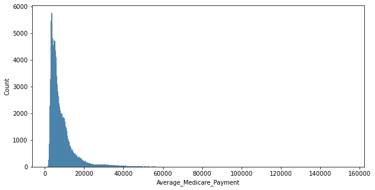

```python
plt.figure(figsize=(10,5))
sns.histplot(data['Average_Medicare_Payment'])
```

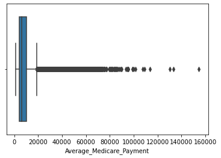

```python
sns.boxplot(x = 'Average_Medicare_Payment', data = data)
```

- From those 2 plots we can see 75% of the charges are under 10,000 dollar, but the highest charge amounts to 154,620

#### Section 2.1.2: Distribtion of Total Discharges

```python
# Distribution plots of total discharges
data['Total_Discharges'].describe()
```

```
count    163065.000000
mean         42.776304
std          51.104042
min          11.000000
25%          17.000000
50%          27.000000
75%          49.000000
max        3383.000000
Name: Total_Discharges, dtype: float64
```

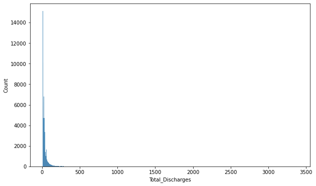

```python
plt.figure(figsize=(10,6))
sns.histplot(data['Total_Discharges'])
```

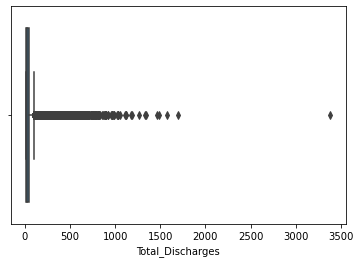

```python
sns.boxplot(x = 'Total_Discharges', data = data)
```

- From those 2 plots we can see 75% of total number of discharges are under 50, but the highest number of discharge is over 3000.

### Section 2.2: Count by State

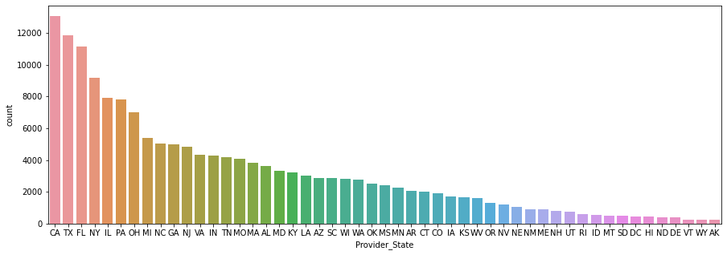

```python
# data['Provider_State'].value_counts()
plt.figure(figsize=(15,5))
sns.countplot(x='Provider_State',data=data,order=data['Provider_State'].value_counts().index)
#plt.xticks(rotation = 90)
#ax = plt.gca()
#for p in ax.patches:
#    ax.text(p.get_x() + p.get_width()/2., p.get_height(), '%d' % int(p.get_height()),
#            fontsize=12, color='blue', ha='center', va='bottom')
plt.rcParams["axes.labelsize"] = 20
```

- From this histogram, California, Texas, and Florid has the highest number of hospital divisions.
- Similar rank compared to total population by state

### Section 2.3: Count of top 20 cities

```python
data['Provider_Name'].value_counts()
```

```
GOOD SAMARITAN HOSPITAL                  633
ST JOSEPH MEDICAL CENTER                 427
MERCY MEDICAL CENTER                     357
MERCY HOSPITAL                           347
ST JOSEPH HOSPITAL                       343
                                        ...
J PAUL JONES HOSPITAL                      1
GREATER BATON ROUGE SURGICAL HOSPITAL      1
FAIRWAY MEDICAL CENTER                     1
MONROE SURGICAL HOSPITAL                   1
EAGLEVILLE HOSPITAL                        1
Name: Provider_Name, Length: 3201, dtype: int64
```

```
(array([ 0,  1,  2,  3,  4,  5,  6,  7,  8,  9, 10, 11, 12, 13, 14, 15, 16,
        17, 18, 19]),
 [Text(0, 0, 'CHICAGO'),
```

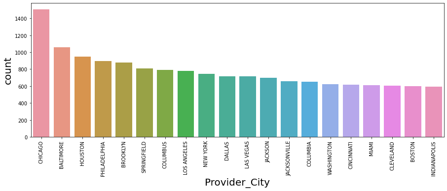

```python
plt.figure(figsize=(15,5))
ch = sns.countplot(x='Provider_City',data=data,order=data['Provider_City'].value_counts()[:20].index)
plt.xticks(rotation = 90)
# junk = ch.set_xticklabels(ch.get_xticklabels()) # Use this line to collect the text prints

#ax = plt.gca()
#plt.rcParams["axes.labelsize"] = 20


# b.set_xlabel("X Label",fontsize=30)
# b.set_ylabel("Y Label",fontsize=20)
# b.tick_params(labelsize=5)

# for p in ax.patches:
#     ax.text(p.get_x() + p.get_width()/2., p.get_height(), '%d' % int(p.get_height()),
#             fontsize=12, color='blue', ha='center', va='bottom')
# plt.rcParams["axes.labelsize"] = 20
```

- The above text are from matplotlib.
- We really do not want to print the text.
- You can assign them to "_" to throw them away.

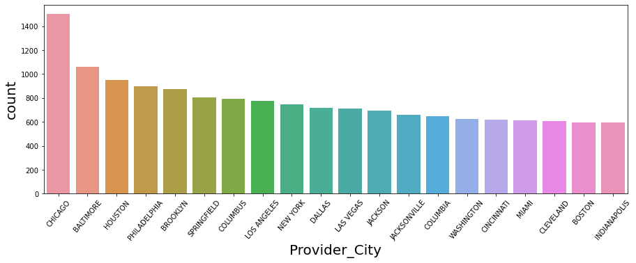

```python
# This will look better
plt.figure(figsize=(15,5))
txt = data['Provider_City'].value_counts()[:20].index

chart = sns.countplot(
    x='Provider_City' ,data=data , order=txt
)

_ = chart.set_xticklabels(chart.get_xticklabels(), rotation=50)
plt.rcParams["axes.labelsize"] = 10
```

- From this histogram, Chicago, Baltimore, and Houston has the highest number of hospital divisions.

### Section 2.5: Count of top 20 HRR

- Hospital referral regions (HRRs) are geographic delineations created by the Dartmouth Atlas of Health Care (an organization committed to studying healthcare markets in the United States) to clearly define unique healthcare market regions.

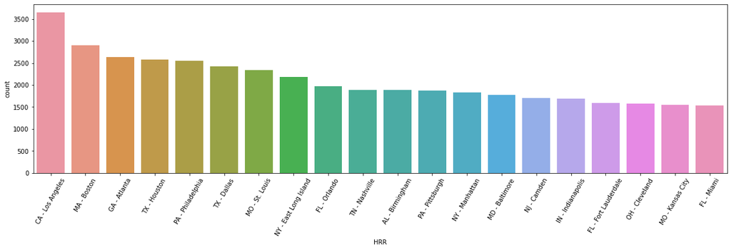

```python
plt.figure(figsize=(20,5))
txt = data['HRR'].value_counts()[:20].index

chart = sns.countplot(
    x='HRR' ,data=data , order=txt
)

_ = chart.set_xticklabels(chart.get_xticklabels(), rotation=60)
plt.rcParams["axes.labelsize"] = 10
```

- From this histogram, CA-Los Angeles, MA-Boston, and GA-Atlanta has the highest number of hospital divisions.

### Section 2.5: Count of top 10 DRG

```python
data['DRG'].value_counts()
```

```
194 - SIMPLE PNEUMONIA & PLEURISY W CC                                      3023
690 - KIDNEY & URINARY TRACT INFECTIONS W/O MCC                             2989
292 - HEART FAILURE & SHOCK W CC                                            2953
392 - ESOPHAGITIS, GASTROENT & MISC DIGEST DISORDERS W/O MCC                2950
641 - MISC DISORDERS OF NUTRITION,METABOLISM,FLUIDS/ELECTROLYTES W/O MCC    2899
                                                                            ...
315 - OTHER CIRCULATORY SYSTEM DIAGNOSES W CC                                859
473 - CERVICAL SPINAL FUSION W/O CC/MCC                                      846
917 - POISONING & TOXIC EFFECTS OF DRUGS W MCC                               843
251 - PERC CARDIOVASC PROC W/O CORONARY ARTERY STENT W/O MCC                 727
885 - PSYCHOSES                                                              613
Name: DRG, Length: 100, dtype: int64
```

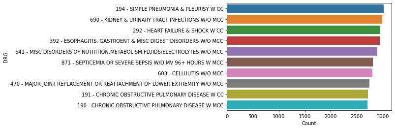

```python
top = data['DRG'].value_counts()[:10].to_frame().reset_index()
top.columns = ['DRG','Count']
s= sns.barplot(y = 'DRG', x = 'Count', data = top, order = top['DRG'][:10])
```

- From this plot, '194 - simple pneumonia', '690 - Kidney & urinary infections', and '292 - heart failure & stock' are the most common treatment in hospitals.

### Section 2.6: Count of bottom 10 DRG

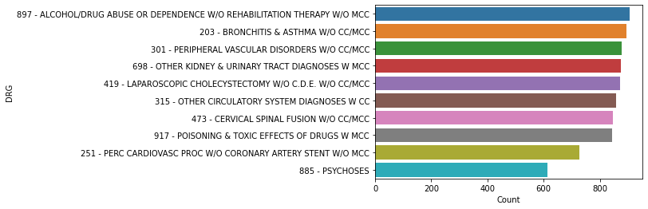

```python
bottom = data['DRG'].value_counts()[-10:].to_frame().reset_index()
bottom.columns = ['DRG','Count']
s= sns.barplot(y = 'DRG', x = 'Count', data = bottom, order = bottom['DRG'][:10])
```

- From this plot, '885 - Psychoses' and '251 - perc cardiovasc' are the least common treatment in hospitals.

### Section 2.7: Top 10 expensive treatments

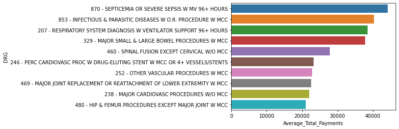

```python
expensive = data.groupby('DRG')['Average_Total_Payments'].mean().sort_values(ascending = False).reset_index()[:10]
s = sns.barplot(y = 'DRG', x = 'Average_Total_Payments', data = expensive, order = expensive['DRG'][:10])
```

- From this plot, '870 - Septicemia or severe sepsis w mv 96+hours' is the most expensive treatment, followed by '853 - infectious & parasitc diseases' and '207 - respiratory system diagnosis'.

### Section 2.8: Top 10 cheap treatments

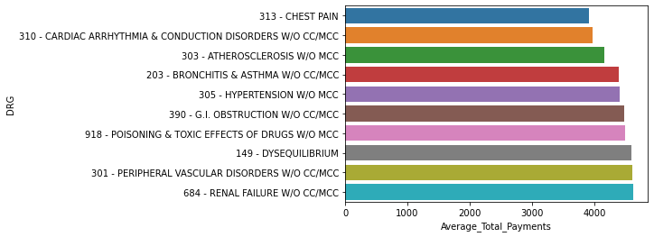

```python
cheap = data.groupby('DRG')['Average_Total_Payments'].mean().sort_values().reset_index()[:10]
s = sns.barplot(y = 'DRG', x = 'Average_Total_Payments', data = cheap, order = cheap['DRG'][:10])
```

- From this plot, '313 - chest pain' is the cheapest treatment, followed by '310 - cardiac arrhythmia' and '303- atherosclerosis'.

### Section 2.9: Top 10 hospitals with most discharges

```python
d = data.groupby('Provider_Id')['Total_Discharges'].sum().sort_values(ascending = False).reset_index()[:10]

lst = []
for val in d['Provider_Id']:
    lst.append(data[data['Provider_Id'] == val]['Provider_Name'].drop_duplicates().tolist()[0])

d['Provider_Name'] = lst
```

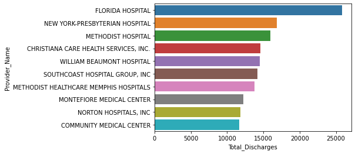

```python
s = sns.barplot(y = 'Provider_Name', x = 'Total_Discharges', data = d, order = d['Provider_Name'][:10])
```

- From this plot, Florida hospital, New York- Presbyterian hospital, and Methodist hospital have the highest number of total discharges, summing all the treatments.

## Section 3: Feature Engineering

#### Discussions:

- Think of the objective: "Detect any hospital that may abuse the resources compared to the average of its peers of the same DRG and State."
- A feature should be able to "detect any hospital...". The above table does not have hospitals.
- The above table is the benchmark. Are they features?

### Section 3.1: Create the benchmark table - State & DRG average

```python
benchmark = data.groupby(['Provider_State','DRG'])['Average_Total_Payments'].mean().reset_index()
benchmark.columns = ['Provider_State','DRG','Avg_Payment_ByStateDRG']
benchmark.head()
```

|  | Provider_State | DRG | Avg_Payment_ByStateDRG |
| --- | --- | --- | --- |
| 0 | AK | 039 - EXTRACRANIAL PROCEDURES W/O CC/MCC | 8401.950000 |
| 1 | AK | 057 - DEGENERATIVE NERVOUS SYSTEM DISORDERS W/... | 8799.000000 |
| 2 | AK | 064 - INTRACRANIAL HEMORRHAGE OR CEREBRAL INFA... | 21608.010000 |
| 3 | AK | 065 - INTRACRANIAL HEMORRHAGE OR CEREBRAL INFA... | 12555.548333 |
| 4 | AK | 066 - INTRACRANIAL HEMORRHAGE OR CEREBRAL INFA... | 9275.867500 |

#### Discussions:

- There is no label to train a supervised model. What are the unsupervised techniques that you can think of?
- How do we validate an unsupervised model outcome?
- What will happen if you have a bad feature in an unsupervised model?

### Section 3.2: Create Features

#### Section 3.2.1: The ratio to mean average medicare payment by RDG

##### Thought Process:

- The average treatment cost should be similar for the same treatment DRG

```python
# create mean average medicare payment group by DRG
benchmark = data.groupby(['DRG'])['Average_Medicare_Payment'].mean().reset_index()
benchmark.columns = ['DRG','Avg_Payment_ByDRG']
benchmark.head()
```

|  | DRG | Avg_Payment_ByDRG |
| --- | --- | --- |
| 0 | 039 - EXTRACRANIAL PROCEDURES W/O CC/MCC | 5555.837525 |
| 1 | 057 - DEGENERATIVE NERVOUS SYSTEM DISORDERS W/... | 5701.676570 |
| 2 | 064 - INTRACRANIAL HEMORRHAGE OR CEREBRAL INFA... | 12112.849445 |
| 3 | 065 - INTRACRANIAL HEMORRHAGE OR CEREBRAL INFA... | 6781.501785 |
| 4 | 066 - INTRACRANIAL HEMORRHAGE OR CEREBRAL INFA... | 4469.203560 |

```python
# add the benchmark to the dataset
df1 = pd.merge(data, benchmark, how='left', on=['DRG'])
# Feature 1: ratio of average medicare payment and mean average medicare payment by DRG
df1['drg_avg_ratio_amount'] = np.where(df1['Avg_Payment_ByDRG']==0,0, df1['Average_Medicare_Payment'] / df1['Avg_Payment_ByDRG'])
df1['drg_avg_ratio_amount'].describe()
```

```
count    163065.000000
mean          1.000000
std           0.281375
min           0.337408
25%           0.820838
50%           0.917180
75%           1.090344
max           7.672359
Name: drg_avg_ratio_amount, dtype: float64
```

```python
# cut by percentile for plotting
var = 'drg_avg_ratio_amount'
binned_var = var + '_D'
percentile = [0,0.01,0.05,0.2,0.5,0.8,0.95,0.99,1]
df1[binned_var] = pd.qcut(df1[var],percentile)
```

```
[Text(0, 0, '(0.336, 0.663]'),
```

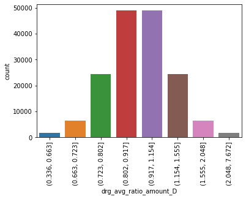

```python
g = sns.countplot(x="drg_avg_ratio_amount_D", data=df1)
g.set_xticklabels(g.get_xticklabels(), rotation=90)
```

```python
df1[df1['drg_avg_ratio_amount']>2].head()
```

|  | DRG | Provider_Id | Provider_Name | Provider_StreetAddress | Provider_City | Provider_State | Provider_Zipcode | Hospital_referral_region_desp | Total_Discharges | Average_Total_Payments | Average_Medicare_Payment | HRR | Avg_Payment_ByDRG | drg_avg_ratio_amount | drg_avg_ratio_amount_D |
| --- | --- | --- | --- | --- | --- | --- | --- | --- | --- | --- | --- | --- | --- | --- | --- |
| 114 | 039 - EXTRACRANIAL PROCEDURES W/O CC/MCC | 50441 | STANFORD HOSPITAL | 300 PASTEUR DRIVE | STANFORD | CA | 94305 | CA - San Mateo County | 27 | 12396.29 | 11483.40 | CA - San Mateo County | 5555.837525 | 2.066907 | (2.048, 7.672] |
| 449 | 039 - EXTRACRANIAL PROCEDURES W/O CC/MCC | 210009 | JOHNS HOPKINS HOSPITAL, THE | 600 NORTH WOLFE STREET | BALTIMORE | MD | 21287 | MD - Baltimore | 36 | 12856.22 | 11891.22 | MD - Baltimore | 5555.837525 | 2.140311 | (2.048, 7.672] |
| 456 | 039 - EXTRACRANIAL PROCEDURES W/O CC/MCC | 210029 | JOHNS HOPKINS BAYVIEW MEDICAL CENTER | 4940 EASTERN AVENUE | BALTIMORE | MD | 21224 | MD - Baltimore | 11 | 16878.45 | 15855.18 | MD - Baltimore | 5555.837525 | 2.853788 | (2.048, 7.672] |
| 457 | 039 - EXTRACRANIAL PROCEDURES W/O CC/MCC | 210032 | UNION HOSPITAL OF CECIL COUNTY | 106 BOW STREET | ELKTON | MD | 21921 | DE - Wilmington | 12 | 12268.50 | 11335.83 | DE - Wilmington | 5555.837525 | 2.040346 | (1.555, 2.048] |
| 690 | 039 - EXTRACRANIAL PROCEDURES W/O CC/MCC | 330195 | LONG ISLAND JEWISH MEDICAL CENTER | 270 - 05 76TH AVENUE | NEW HYDE PARK | NY | 11040 | NY - East Long Island | 11 | 13895.09 | 13280.54 | NY - East Long Island | 5555.837525 | 2.390376 | (2.048, 7.672] |

```python
df = data.copy()
df['drg_avg_ratio_amount'] = df1['drg_avg_ratio_amount']
```

Conclusion: The feature can detect hospital receive more payment (abuse resources) than the average treatment payment among peers for the specific treatment category. The higher the ratio, the higher the likelihood.

#### Section 3.2.2: The ratio to median average medicare payment by RDG

- Notice the only difference to the above code is "median".
- The reason to use "median" is that median returns the central tendency for skewed number distributions. Extreme values (anomalies) can be detected by comparsion.

```python
# create median average medicare payment group by DRG
benchmark = data.groupby(['DRG'])['Average_Medicare_Payment'].median().reset_index()
benchmark.columns = ['DRG','Median_Payment_ByDRG']
benchmark.head()
```

|  | DRG | Median_Payment_ByDRG |
| --- | --- | --- |
| 0 | 039 - EXTRACRANIAL PROCEDURES W/O CC/MCC | 5269.280 |
| 1 | 057 - DEGENERATIVE NERVOUS SYSTEM DISORDERS W/... | 5104.780 |
| 2 | 064 - INTRACRANIAL HEMORRHAGE OR CEREBRAL INFA... | 10956.160 |
| 3 | 065 - INTRACRANIAL HEMORRHAGE OR CEREBRAL INFA... | 6167.510 |
| 4 | 066 - INTRACRANIAL HEMORRHAGE OR CEREBRAL INFA... | 4079.575 |

```python
# add the benchmark to the dataset
df2 = pd.merge(data, benchmark, how='left', on=['DRG'])
# Feature 2: ratio of average medicare payment and median average medicare payment by DRG
df2['drg_median_ratio_amount'] = np.where(df2['Median_Payment_ByDRG']==0,0, df2['Average_Medicare_Payment'] / df2['Median_Payment_ByDRG'])
df2['drg_median_ratio_amount'].describe()
```

```
count    163065.000000
mean          1.091445
std           0.308066
min           0.385932
25%           0.896059
50%           1.000000
75%           1.188709
max           8.420986
Name: drg_median_ratio_amount, dtype: float64
```

```python
# cut by percentile for plotting
var = 'drg_median_ratio_amount'
binned_var = var + '_D'
percentile = [0,0.01,0.05,0.2,0.5,0.8,0.95,0.99,1]
df2[binned_var] = pd.qcut(df2[var],percentile)
```

```
[Text(0, 0, '(0.385, 0.726]'),
```

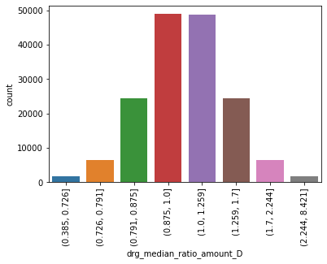

```python
g = sns.countplot(x="drg_median_ratio_amount_D", data=df2)
g.set_xticklabels(g.get_xticklabels(), rotation=90)
```

```python
df2[df2['drg_median_ratio_amount']>2].head()
```

|  | DRG | Provider_Id | Provider_Name | Provider_StreetAddress | Provider_City | Provider_State | Provider_Zipcode | Hospital_referral_region_desp | Total_Discharges | Average_Total_Payments | Average_Medicare_Payment | HRR | Median_Payment_ByDRG | drg_median_ratio_amount | drg_median_ratio_amount_D |
| --- | --- | --- | --- | --- | --- | --- | --- | --- | --- | --- | --- | --- | --- | --- | --- |
| 97 | 039 - EXTRACRANIAL PROCEDURES W/O CC/MCC | 50262 | RONALD REAGAN UCLA MEDICAL CENTER | 757 WESTWOOD PLAZA | LOS ANGELES | CA | 90095 | CA - Los Angeles | 13 | 11899.76 | 10946.84 | CA - Los Angeles | 5269.28 | 2.077483 | (1.7, 2.244] |
| 114 | 039 - EXTRACRANIAL PROCEDURES W/O CC/MCC | 50441 | STANFORD HOSPITAL | 300 PASTEUR DRIVE | STANFORD | CA | 94305 | CA - San Mateo County | 27 | 12396.29 | 11483.40 | CA - San Mateo County | 5269.28 | 2.179311 | (1.7, 2.244] |
| 449 | 039 - EXTRACRANIAL PROCEDURES W/O CC/MCC | 210009 | JOHNS HOPKINS HOSPITAL, THE | 600 NORTH WOLFE STREET | BALTIMORE | MD | 21287 | MD - Baltimore | 36 | 12856.22 | 11891.22 | MD - Baltimore | 5269.28 | 2.256707 | (2.244, 8.421] |
| 456 | 039 - EXTRACRANIAL PROCEDURES W/O CC/MCC | 210029 | JOHNS HOPKINS BAYVIEW MEDICAL CENTER | 4940 EASTERN AVENUE | BALTIMORE | MD | 21224 | MD - Baltimore | 11 | 16878.45 | 15855.18 | MD - Baltimore | 5269.28 | 3.008984 | (2.244, 8.421] |
| 457 | 039 - EXTRACRANIAL PROCEDURES W/O CC/MCC | 210032 | UNION HOSPITAL OF CECIL COUNTY | 106 BOW STREET | ELKTON | MD | 21921 | DE - Wilmington | 12 | 12268.50 | 11335.83 | DE - Wilmington | 5269.28 | 2.151305 | (1.7, 2.244] |

```python
df['drg_median_ratio_amount'] = df2['drg_median_ratio_amount']
```

Conclusion: The feature can detect hospital receive more payment (abuse resources) than the average treatment payment among peers for specific treatment. The higher the ratio, the higher the likelihood.

#### Section 3.2.3: The ratio to mean average medicare payment by RDG and State

##### Thought Process:

- The medicare cost might be different by states
- In the same state, the treatment cost should be similar for each RDG

```python
# create mean average medicare payment group by DRG and State
benchmark = data.groupby(['DRG','Provider_State'])['Average_Medicare_Payment'].mean().reset_index()
benchmark.columns = ['DRG','Provider_State','Avg_Payment_ByDRGState']
benchmark.head()
```

|  | DRG | Provider_State | Avg_Payment_ByDRGState |
| --- | --- | --- | --- |
| 0 | 039 - EXTRACRANIAL PROCEDURES W/O CC/MCC | AK | 6413.780000 |
| 1 | 039 - EXTRACRANIAL PROCEDURES W/O CC/MCC | AL | 4599.593043 |
| 2 | 039 - EXTRACRANIAL PROCEDURES W/O CC/MCC | AR | 4938.712500 |
| 3 | 039 - EXTRACRANIAL PROCEDURES W/O CC/MCC | AZ | 5912.832917 |
| 4 | 039 - EXTRACRANIAL PROCEDURES W/O CC/MCC | CA | 6878.954925 |

```python
# add the benchmark to the dataset
df3 = pd.merge(data, benchmark, how='left', on=['DRG','Provider_State'])
# Feature 3: ratio of average medicare payment and mean average medicare payment by DRG and State
df3['drg_state_avg_ratio_amount'] = np.where(df3['Avg_Payment_ByDRGState']==0,0, df3['Average_Medicare_Payment'] / df3['Avg_Payment_ByDRGState'])
df3['drg_state_avg_ratio_amount'].describe()
```

```
count    163065.000000
mean          1.000000
std           0.215091
min           0.339831
25%           0.868395
50%           0.954250
75%           1.071483
max           5.174415
Name: drg_state_avg_ratio_amount, dtype: float64
```

```python
# cut by percentile for plotting
var = 'drg_state_avg_ratio_amount'
binned_var = var + '_D'
percentile = [0,0.01,0.05,0.2,0.5,0.8,0.95,0.99,1]
df3[binned_var] = pd.qcut(df3[var],percentile)
```

```
[Text(0, 0, '(0.339, 0.655]'),
```

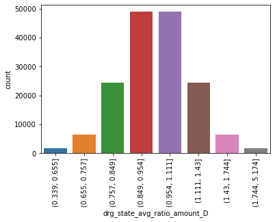

```python
g = sns.countplot(x="drg_state_avg_ratio_amount_D", data=df3)
g.set_xticklabels(g.get_xticklabels(), rotation=90)
```

```python
df3[df3['drg_state_avg_ratio_amount']>2].head()
```

|  | DRG | Provider_Id | Provider_Name | Provider_StreetAddress | Provider_City | Provider_State | Provider_Zipcode | Hospital_referral_region_desp | Total_Discharges | Average_Total_Payments | Average_Medicare_Payment | HRR | Avg_Payment_ByDRGState | drg_state_avg_ratio_amount | drg_state_avg_ratio_amount_D |
| --- | --- | --- | --- | --- | --- | --- | --- | --- | --- | --- | --- | --- | --- | --- | --- |
| 1172 | 057 - DEGENERATIVE NERVOUS SYSTEM DISORDERS W/... | 50276 | CONTRA COSTA REGIONAL MEDICAL CENTER | 2500 ALHAMBRA AVE | MARTINEZ | CA | 94553 | CA - Contra Costa County | 23 | 19239.30 | 18363.08 | CA - Contra Costa County | 7506.485256 | 2.446295 | (1.744, 5.174] |
| 1191 | 057 - DEGENERATIVE NERVOUS SYSTEM DISORDERS W/... | 50441 | STANFORD HOSPITAL | 300 PASTEUR DRIVE | STANFORD | CA | 94305 | CA - San Mateo County | 16 | 25519.43 | 22553.56 | CA - San Mateo County | 7506.485256 | 3.004543 | (1.744, 5.174] |
| 1258 | 057 - DEGENERATIVE NERVOUS SYSTEM DISORDERS W/... | 100022 | JACKSON MEMORIAL HOSPITAL | 1611 NW 12TH AVE | MIAMI | FL | 33136 | FL - Miami | 29 | 12789.27 | 11467.62 | FL - Miami | 4759.258922 | 2.409539 | (1.744, 5.174] |
| 1417 | 057 - DEGENERATIVE NERVOUS SYSTEM DISORDERS W/... | 140150 | UNIVERSITY OF ILLINOIS HOSPITAL | 1740 WEST TAYLOR ST SUITE 1400 | CHICAGO | IL | 60612 | IL - Chicago | 16 | 12215.06 | 11442.81 | IL - Chicago | 5428.791471 | 2.107801 | (1.744, 5.174] |
| 1554 | 057 - DEGENERATIVE NERVOUS SYSTEM DISORDERS W/... | 210009 | JOHNS HOPKINS HOSPITAL, THE | 600 NORTH WOLFE STREET | BALTIMORE | MD | 21287 | MD - Baltimore | 83 | 24865.61 | 22873.49 | MD - Baltimore | 8352.411622 | 2.738549 | (1.744, 5.174] |

```python
df['drg_state_avg_ratio_amount'] = df3['drg_state_avg_ratio_amount']
```

Conclusion: The feature can detect hospital receive more payment (abuse resources) than the average treatment payment among peers in the same state and for the same treatment. The higher the ratio, the higher the likelihood.

#### Section 3.2.4: The ratio to median average medicare payment by RDG and State

- Notice the only difference to the above code is "median".

```python
# create median average medicare payment group by DRG and State
benchmark = data.groupby(['DRG','Provider_State'])['Average_Medicare_Payment'].median().reset_index()
benchmark.columns = ['DRG','Provider_State','Median_Payment_ByDRGState']
benchmark.head()
```

|  | DRG | Provider_State | Median_Payment_ByDRGState |
| --- | --- | --- | --- |
| 0 | 039 - EXTRACRANIAL PROCEDURES W/O CC/MCC | AK | 6413.780 |
| 1 | 039 - EXTRACRANIAL PROCEDURES W/O CC/MCC | AL | 4471.680 |
| 2 | 039 - EXTRACRANIAL PROCEDURES W/O CC/MCC | AR | 4607.400 |
| 3 | 039 - EXTRACRANIAL PROCEDURES W/O CC/MCC | AZ | 5669.805 |
| 4 | 039 - EXTRACRANIAL PROCEDURES W/O CC/MCC | CA | 6639.330 |

```python
# add the benchmark to the dataset
df4 = pd.merge(data, benchmark, how='left', on=['DRG','Provider_State'])
# Feature 4: ratio of average medicare payment and median average medicare payment by DRG and State
df4['drg_state_median_ratio_amount'] = np.where(df4['Median_Payment_ByDRGState']==0,0, df4['Average_Medicare_Payment'] / df4['Median_Payment_ByDRGState'])
df4['drg_state_median_ratio_amount'].describe()
```

```
count    163065.000000
mean          1.055484
std           0.234139
min           0.367836
25%           0.916191
50%           1.000000
75%           1.121178
max           6.030981
Name: drg_state_median_ratio_amount, dtype: float64
```

```python
# cut by percentile for plotting
var = 'drg_state_median_ratio_amount'
binned_var = var + '_D'
percentile = [0,0.01,0.05,0.2,0.5,0.8,0.95,0.99,1]
df4[binned_var] = pd.qcut(df4[var],percentile)
```

```
[Text(0, 0, '(0.367, 0.714]'),
```

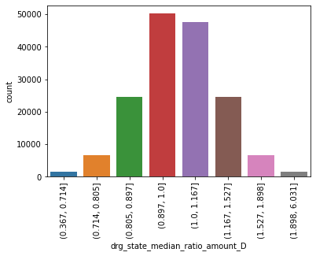

```python
g = sns.countplot(x="drg_state_median_ratio_amount_D", data=df4)
g.set_xticklabels(g.get_xticklabels(), rotation=90)
```

```python
df4[df4['drg_state_median_ratio_amount']>2].head()
```

|  | DRG | Provider_Id | Provider_Name | Provider_StreetAddress | Provider_City | Provider_State | Provider_Zipcode | Hospital_referral_region_desp | Total_Discharges | Average_Total_Payments | Average_Medicare_Payment | HRR | Median_Payment_ByDRGState | drg_state_median_ratio_amount | drg_state_median_ratio_amount_D |
| --- | --- | --- | --- | --- | --- | --- | --- | --- | --- | --- | --- | --- | --- | --- | --- |
| 456 | 039 - EXTRACRANIAL PROCEDURES W/O CC/MCC | 210029 | JOHNS HOPKINS BAYVIEW MEDICAL CENTER | 4940 EASTERN AVENUE | BALTIMORE | MD | 21224 | MD - Baltimore | 11 | 16878.45 | 15855.18 | MD - Baltimore | 7340.710 | 2.159897 | (1.898, 6.031] |
| 690 | 039 - EXTRACRANIAL PROCEDURES W/O CC/MCC | 330195 | LONG ISLAND JEWISH MEDICAL CENTER | 270 - 05 76TH AVENUE | NEW HYDE PARK | NY | 11040 | NY - East Long Island | 11 | 13895.09 | 13280.54 | NY - East Long Island | 6358.070 | 2.088769 | (1.898, 6.031] |
| 1172 | 057 - DEGENERATIVE NERVOUS SYSTEM DISORDERS W/... | 50276 | CONTRA COSTA REGIONAL MEDICAL CENTER | 2500 ALHAMBRA AVE | MARTINEZ | CA | 94553 | CA - Contra Costa County | 23 | 19239.30 | 18363.08 | CA - Contra Costa County | 6800.435 | 2.700280 | (1.898, 6.031] |
| 1186 | 057 - DEGENERATIVE NERVOUS SYSTEM DISORDERS W/... | 50376 | LAC/HARBOR-UCLA MED CENTER | 1000 W CARSON ST | TORRANCE | CA | 90509 | CA - Los Angeles | 13 | 15070.23 | 14381.00 | CA - Los Angeles | 6800.435 | 2.114718 | (1.898, 6.031] |
| 1191 | 057 - DEGENERATIVE NERVOUS SYSTEM DISORDERS W/... | 50441 | STANFORD HOSPITAL | 300 PASTEUR DRIVE | STANFORD | CA | 94305 | CA - San Mateo County | 16 | 25519.43 | 22553.56 | CA - San Mateo County | 6800.435 | 3.316488 | (1.898, 6.031] |

```python
df['drg_state_median_ratio_amount'] = df4['drg_state_median_ratio_amount']
```

Conclusion: The feature can detect hospital receive more payment (abuse resources) than the average treatment payment among peers in the same state and for the same treatment. The higher the ratio, the higher the likelihood.

#### Section 3.2.5: The ratio to mean average medicare payment by RDG, State, and City

##### Thought Process:

- Even in the same state, big city might cost more becuase of advanced technology.

```python
# create mean average medicare payment group by state, City and DRG
benchmark = data.groupby(['DRG','Provider_State','Provider_City'])['Average_Medicare_Payment'].mean().reset_index()
benchmark.columns = ['DRG','Provider_State','Provider_City','Avg_Payment_ByDRGStateCity']
```

```python
# add the benchmark to the dataset
df5 = pd.merge(data, benchmark, how='left', on=['DRG','Provider_State','Provider_City'])
# Feature 5: ratio of average medicare payment and mean average medicare payment by DRG and State and City
df5['drg_state_city_avg_ratio_amount'] = np.where(df5['Avg_Payment_ByDRGStateCity']==0,0, df5['Average_Medicare_Payment'] / df5['Avg_Payment_ByDRGStateCity'])
df5['drg_state_city_avg_ratio_amount'].describe()
```

```
count    163065.000000
mean          1.000000
std           0.101956
min           0.261737
25%           1.000000
50%           1.000000
75%           1.000000
max           3.846861
Name: drg_state_city_avg_ratio_amount, dtype: float64
```

```python
# cut by percentile for plotting
var = 'drg_state_city_avg_ratio_amount'
binned_var = var + '_D'
percentile = [0,0.01,0.05,0.2,0.5,0.8,0.95,0.99,1]
df5[binned_var] = pd.qcut(df5[var],percentile, duplicates = 'drop')
```

```
[Text(0, 0, '(0.261, 0.719]'),
```

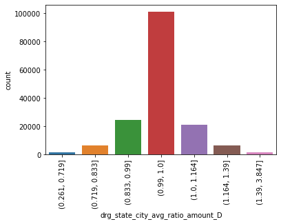

```python
g = sns.countplot(x="drg_state_city_avg_ratio_amount_D", data=df5)
g.set_xticklabels(g.get_xticklabels(), rotation=90)
```

```python
df5[df5['drg_state_city_avg_ratio_amount']>2].head()
```

|  | DRG | Provider_Id | Provider_Name | Provider_StreetAddress | Provider_City | Provider_State | Provider_Zipcode | Hospital_referral_region_desp | Total_Discharges | Average_Total_Payments | Average_Medicare_Payment | HRR | Avg_Payment_ByDRGStateCity | drg_state_city_avg_ratio_amount | drg_state_city_avg_ratio_amount_D |
| --- | --- | --- | --- | --- | --- | --- | --- | --- | --- | --- | --- | --- | --- | --- | --- |
| 1554 | 057 - DEGENERATIVE NERVOUS SYSTEM DISORDERS W/... | 210009 | JOHNS HOPKINS HOSPITAL, THE | 600 NORTH WOLFE STREET | BALTIMORE | MD | 21287 | MD - Baltimore | 83 | 24865.61 | 22873.49 | MD - Baltimore | 10357.178333 | 2.208467 | (1.39, 3.847] |
| 2992 | 064 - INTRACRANIAL HEMORRHAGE OR CEREBRAL INFA... | 210009 | JOHNS HOPKINS HOSPITAL, THE | 600 NORTH WOLFE STREET | BALTIMORE | MD | 21287 | MD - Baltimore | 64 | 50882.40 | 48632.28 | MD - Baltimore | 20316.811667 | 2.393696 | (1.39, 3.847] |
| 19642 | 189 - PULMONARY EDEMA & RESPIRATORY FAILURE | 210009 | JOHNS HOPKINS HOSPITAL, THE | 600 NORTH WOLFE STREET | BALTIMORE | MD | 21287 | MD - Baltimore | 26 | 38987.46 | 36201.69 | MD - Baltimore | 17941.443636 | 2.017769 | (1.39, 3.847] |
| 34560 | 194 - SIMPLE PNEUMONIA & PLEURISY W CC | 670006 | THE HOSPITAL AT WESTLAKE MEDICAL CENTER | 5656 BEE CAVES ROAD, SUITE M-302 | AUSTIN | TX | 78746 | TX - Austin | 18 | 14725.83 | 13856.27 | TX - Austin | 6531.490000 | 2.121456 | (1.39, 3.847] |
| 37139 | 195 - SIMPLE PNEUMONIA & PLEURISY W/O CC/MCC | 670006 | THE HOSPITAL AT WESTLAKE MEDICAL CENTER | 5656 BEE CAVES ROAD, SUITE M-302 | AUSTIN | TX | 78746 | TX - Austin | 20 | 11471.25 | 10407.05 | TX - Austin | 4439.553333 | 2.344166 | (1.39, 3.847] |

```python
df['drg_state_city_avg_ratio_amount'] = df5['drg_state_city_avg_ratio_amount']
```

Conclusion: The feature can detect hospital receive more payment (abuse resources) than the average treatment payment among peers in the same state, city and for the same treatment. The higher the ratio, the higher the likelihood.

#### Section 3.2.6: The ratio to median average medicare payment by RDG, State, and City

- Notice the only difference to the above code is "median".

```python
# create median average medicare payment group by DRG, state, and city
benchmark = data.groupby(['DRG','Provider_State','Provider_City'])['Average_Medicare_Payment'].median().reset_index()
benchmark.columns = ['DRG','Provider_State','Provider_City','Median_Payment_ByDRGStateCity']
```

```python
# add the benchmark to the dataset
df6 = pd.merge(data, benchmark, how='left', on=['DRG','Provider_State','Provider_City'])
# Feature 6: ratio of average medicare payment and median average medicare payment by DRG and State and City
df6['drg_state_city_median_ratio_amount'] = np.where(df6['Median_Payment_ByDRGStateCity']==0,0, df6['Average_Medicare_Payment'] / df6['Median_Payment_ByDRGStateCity'])
df6['drg_state_city_median_ratio_amount'].describe()
```

```
count    163065.000000
mean          1.009285
std           0.114675
min           0.261737
25%           1.000000
50%           1.000000
75%           1.000000
max           5.733904
Name: drg_state_city_median_ratio_amount, dtype: float64
```

```python
# cut by percentile for plotting
var = 'drg_state_city_median_ratio_amount'
binned_var = var + '_D'
percentile = [0,0.01,0.05,0.2,0.5,0.8,0.95,0.99,1]
df6[binned_var] = pd.qcut(df6[var],percentile, duplicates = 'drop')
```

```
[Text(0, 0, '(0.261, 0.732]'),
```

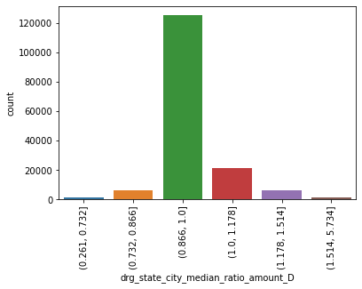

```python
g = sns.countplot(x="drg_state_city_median_ratio_amount_D", data=df6)
g.set_xticklabels(g.get_xticklabels(), rotation=90)
```

```python
df6[df6['drg_state_city_median_ratio_amount']>2].head()
```

|  | DRG | Provider_Id | Provider_Name | Provider_StreetAddress | Provider_City | Provider_State | Provider_Zipcode | Hospital_referral_region_desp | Total_Discharges | Average_Total_Payments | Average_Medicare_Payment | HRR | Median_Payment_ByDRGStateCity | drg_state_city_median_ratio_amount | drg_state_city_median_ratio_amount_D |
| --- | --- | --- | --- | --- | --- | --- | --- | --- | --- | --- | --- | --- | --- | --- | --- |
| 1186 | 057 - DEGENERATIVE NERVOUS SYSTEM DISORDERS W/... | 50376 | LAC/HARBOR-UCLA MED CENTER | 1000 W CARSON ST | TORRANCE | CA | 90509 | CA - Los Angeles | 13 | 15070.23 | 14381.00 | CA - Los Angeles | 7124.330 | 2.018576 | (1.514, 5.734] |
| 1517 | 057 - DEGENERATIVE NERVOUS SYSTEM DISORDERS W/... | 180067 | UNIVERSITY OF KENTUCKY HOSPITAL | HOSPITAL ADMINISTRATION | LEXINGTON | KY | 40536 | KY - Lexington | 31 | 9970.45 | 9101.29 | KY - Lexington | 4405.270 | 2.066000 | (1.514, 5.734] |
| 1547 | 057 - DEGENERATIVE NERVOUS SYSTEM DISORDERS W/... | 210002 | UNIVERSITY OF MARYLAND MEDICAL CENTER | 22 S GREENE ST | BALTIMORE | MD | 21201 | MD - Baltimore | 55 | 17210.74 | 15860.05 | MD - Baltimore | 7297.685 | 2.173299 | (1.514, 5.734] |
| 1554 | 057 - DEGENERATIVE NERVOUS SYSTEM DISORDERS W/... | 210009 | JOHNS HOPKINS HOSPITAL, THE | 600 NORTH WOLFE STREET | BALTIMORE | MD | 21287 | MD - Baltimore | 83 | 24865.61 | 22873.49 | MD - Baltimore | 7297.685 | 3.134349 | (1.514, 5.734] |
| 1566 | 057 - DEGENERATIVE NERVOUS SYSTEM DISORDERS W/... | 210029 | JOHNS HOPKINS BAYVIEW MEDICAL CENTER | 4940 EASTERN AVENUE | BALTIMORE | MD | 21224 | MD - Baltimore | 103 | 19700.60 | 18407.07 | MD - Baltimore | 7297.685 | 2.522316 | (1.514, 5.734] |

```python
df['drg_state_city_median_ratio_amount'] = df6['drg_state_city_median_ratio_amount']
```

Conclusion: The feature can detect hospital receive more payment (abuse resources) than the average treatment payment among peers in the same state, city and for the same treatment. The higher the ratio, the higher the likelihood.

#### Section 3.2.7: The ratio to mean average medicare payment by HRR

##### Thought process:

- HRR defines unique healthcare market regions
- Same market region should have similar treatment cost

```python
benchmark = data.groupby('HRR')['Average_Medicare_Payment'].mean().reset_index()
benchmark.columns = ['HRR','AVG_payment_byHRR']
benchmark.head()
```

|  | HRR | AVG_payment_byHRR |
| --- | --- | --- |
| 0 | AK - Anchorage | 12958.969437 |
| 1 | AL - Birmingham | 6577.098107 |
| 2 | AL - Dothan | 6012.843618 |
| 3 | AL - Huntsville | 6194.050393 |
| 4 | AL - Mobile | 6356.235942 |

```python
# add the benchmark to the dataset
df7 = pd.merge(data, benchmark, how='left', on=['HRR'])
# Feature 7: ratio of average medicare payment and mean average medicare payment by HRR
df7['hrr_avg_ratio_amount'] = np.where(df7['AVG_payment_byHRR']==0,0, df7['Average_Medicare_Payment'] / df7['AVG_payment_byHRR'])
df7['hrr_avg_ratio_amount'].describe()
```

```
count    163065.000000
mean          1.000000
std           0.812005
min           0.174236
25%           0.508670
50%           0.736932
75%           1.203440
max          16.296198
Name: hrr_avg_ratio_amount, dtype: float64
```

```python
# cut by percentile for plotting
var = 'hrr_avg_ratio_amount'
binned_var = var + '_D'
percentile = [0,0.01,0.05,0.2,0.5,0.8,0.95,0.99,1]
df7[binned_var] = pd.qcut(df7[var],percentile)
```

```
[Text(0, 0, '(0.173, 0.293]'),
```

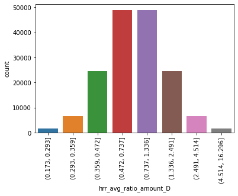

```python
g = sns.countplot(x="hrr_avg_ratio_amount_D", data=df7)
g.set_xticklabels(g.get_xticklabels(), rotation=90)
```

```python
df7[df7['hrr_avg_ratio_amount']>2].head()
```

|  | DRG | Provider_Id | Provider_Name | Provider_StreetAddress | Provider_City | Provider_State | Provider_Zipcode | Hospital_referral_region_desp | Total_Discharges | Average_Total_Payments | Average_Medicare_Payment | HRR | AVG_payment_byHRR | hrr_avg_ratio_amount | hrr_avg_ratio_amount_D |
| --- | --- | --- | --- | --- | --- | --- | --- | --- | --- | --- | --- | --- | --- | --- | --- |
| 2328 | 064 - INTRACRANIAL HEMORRHAGE OR CEREBRAL INFA... | 30023 | FLAGSTAFF MEDICAL CENTER | 1200 NORTH BEAVER STREET | FLAGSTAFF | AZ | 86001 | AZ - Phoenix | 17 | 20742.17 | 19887.76 | AZ - Phoenix | 9213.646886 | 2.158511 | (1.336, 2.491] |
| 2362 | 064 - INTRACRANIAL HEMORRHAGE OR CEREBRAL INFA... | 40118 | NEA BAPTIST MEMORIAL HOSPITAL | 3024 STADIUM BOULEVARD | JONESBORO | AR | 72401 | AR - Jonesboro | 12 | 17535.25 | 16877.66 | AR - Jonesboro | 6982.240196 | 2.417227 | (1.336, 2.491] |
| 2428 | 064 - INTRACRANIAL HEMORRHAGE OR CEREBRAL INFA... | 50228 | SAN FRANCISCO GENERAL HOSPITAL | 1001 POTRERO AVENUE | SAN FRANCISCO | CA | 94110 | CA - San Francisco | 19 | 35275.57 | 34455.00 | CA - San Francisco | 14387.407040 | 2.394803 | (1.336, 2.491] |
| 2439 | 064 - INTRACRANIAL HEMORRHAGE OR CEREBRAL INFA... | 50262 | RONALD REAGAN UCLA MEDICAL CENTER | 757 WESTWOOD PLAZA | LOS ANGELES | CA | 90095 | CA - Los Angeles | 62 | 25330.48 | 24153.85 | CA - Los Angeles | 11797.551443 | 2.047361 | (1.336, 2.491] |
| 2461 | 064 - INTRACRANIAL HEMORRHAGE OR CEREBRAL INFA... | 50348 | UNIVERSITY OF CALIFORNIA IRVINE MED CENTER | 101 CITY DRIVE SOUTH | ORANGE | CA | 92868 | CA - Orange County | 26 | 33918.23 | 33054.88 | CA - Orange County | 10131.079132 | 3.262721 | (2.491, 4.514] |

```python
df['hrr_avg_ratio_amount'] = df7['hrr_avg_ratio_amount']
```

Conclusion: The feature can detect hospital receive more payment (abuse resources) than the average treatment payment among peers in the same referral region. The higher the ratio, the higher the likelihood.

#### Section 3.2.8: The ratio to median average medicare payment by HRR

```python
benchmark = data.groupby('HRR')['Average_Medicare_Payment'].median().reset_index()
benchmark.columns = ['HRR','Median_payment_byHRR']
benchmark.head()
```

|  | HRR | Median_payment_byHRR |
| --- | --- | --- |
| 0 | AK - Anchorage | 9594.930 |
| 1 | AL - Birmingham | 4896.210 |
| 2 | AL - Dothan | 4516.125 |
| 3 | AL - Huntsville | 4778.900 |
| 4 | AL - Mobile | 4557.365 |

```python
# add the benchmark to the dataset
df8 = pd.merge(data, benchmark, how='left', on=['HRR'])
# Feature 8: ratio of average medicare payment and median average medicare payment by HRR
df8['hrr_median_ratio_amount'] = np.where(df8['Median_payment_byHRR']==0,0, df8['Average_Medicare_Payment'] / df8['Median_payment_byHRR'])
df8['hrr_median_ratio_amount'].describe()
```

```
count    163065.000000
mean          1.359133
std           1.107238
min           0.235012
25%           0.689949
50%           1.000000
75%           1.636432
max          22.612327
Name: hrr_median_ratio_amount, dtype: float64
```

```python
# cut by percentile for plotting
var = 'hrr_median_ratio_amount'
binned_var = var + '_D'
percentile = [0,0.01,0.05,0.2,0.5,0.8,0.95,0.99,1]
df8[binned_var] = pd.qcut(df8[var],percentile)
```

```
[Text(0, 0, '(0.23399999999999999, 0.4]'),
```

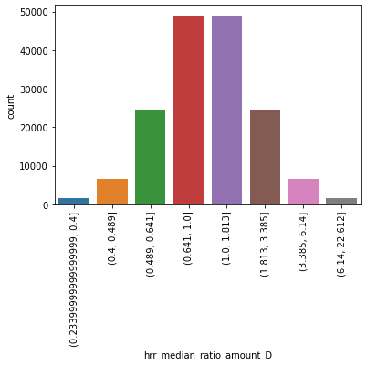

```python
g = sns.countplot(x="hrr_median_ratio_amount_D", data=df8)
g.set_xticklabels(g.get_xticklabels(), rotation=90)
```

```python
df8[df8['hrr_median_ratio_amount']>2].head()
```

|  | DRG | Provider_Id | Provider_Name | Provider_StreetAddress | Provider_City | Provider_State | Provider_Zipcode | Hospital_referral_region_desp | Total_Discharges | Average_Total_Payments | Average_Medicare_Payment | HRR | Median_payment_byHRR | hrr_median_ratio_amount | hrr_median_ratio_amount_D |
| --- | --- | --- | --- | --- | --- | --- | --- | --- | --- | --- | --- | --- | --- | --- | --- |
| 1554 | 057 - DEGENERATIVE NERVOUS SYSTEM DISORDERS W/... | 210009 | JOHNS HOPKINS HOSPITAL, THE | 600 NORTH WOLFE STREET | BALTIMORE | MD | 21287 | MD - Baltimore | 83 | 24865.61 | 22873.49 | MD - Baltimore | 8766.920 | 2.609068 | (1.813, 3.385] |
| 1566 | 057 - DEGENERATIVE NERVOUS SYSTEM DISORDERS W/... | 210029 | JOHNS HOPKINS BAYVIEW MEDICAL CENTER | 4940 EASTERN AVENUE | BALTIMORE | MD | 21224 | MD - Baltimore | 103 | 19700.60 | 18407.07 | MD - Baltimore | 8766.920 | 2.099605 | (1.813, 3.385] |
| 1886 | 057 - DEGENERATIVE NERVOUS SYSTEM DISORDERS W/... | 330234 | WESTCHESTER MEDICAL CENTER | 100 WOODS RD | VALHALLA | NY | 10595 | NY - White Plains | 24 | 17129.08 | 16369.29 | NY - White Plains | 7436.350 | 2.201253 | (1.813, 3.385] |
| 2138 | 057 - DEGENERATIVE NERVOUS SYSTEM DISORDERS W/... | 450018 | UNIVERSITY OF TEXAS MEDICAL BRANCH GAL | 301 UNIVERSITY BOULEVARD | GALVESTON | TX | 77555 | TX - Houston | 16 | 14123.06 | 13205.31 | TX - Houston | 6035.460 | 2.187954 | (1.813, 3.385] |
| 2282 | 064 - INTRACRANIAL HEMORRHAGE OR CEREBRAL INFA... | 10001 | SOUTHEAST ALABAMA MEDICAL CENTER | 1108 ROSS CLARK CIRCLE | DOTHAN | AL | 36301 | AL - Dothan | 84 | 10260.21 | 9167.08 | AL - Dothan | 4516.125 | 2.029855 | (1.813, 3.385] |

```python
df['hrr_median_ratio_amount'] = df8['hrr_median_ratio_amount']
```

Conclusion: The feature can detect hospital receive more payment (abuse resources) than the average treatment payment among peers in the same referral region. The higher the ratio, the higher the likelihood.

#### Section 3.2.9: The ratio to mean average medicare payment by RDG and HRR

##### Thought process:

- Even in same market region, treatment cost differ by DRG

```python
# create mean average medicare payment group by DRG and HRR
benchmark = data.groupby(['DRG','HRR'])['Average_Medicare_Payment'].mean().reset_index()
benchmark.columns = ['DRG','HRR','Avg_Payment_ByDRGHrr']
benchmark.head()
```

|  | DRG | HRR | Avg_Payment_ByDRGHrr |
| --- | --- | --- | --- |
| 0 | 039 - EXTRACRANIAL PROCEDURES W/O CC/MCC | AK - Anchorage | 6413.780000 |
| 1 | 039 - EXTRACRANIAL PROCEDURES W/O CC/MCC | AL - Birmingham | 4604.024615 |
| 2 | 039 - EXTRACRANIAL PROCEDURES W/O CC/MCC | AL - Dothan | 4585.965000 |
| 3 | 039 - EXTRACRANIAL PROCEDURES W/O CC/MCC | AL - Huntsville | 4868.755000 |
| 4 | 039 - EXTRACRANIAL PROCEDURES W/O CC/MCC | AL - Mobile | 4261.122000 |

```python
# add the benchmark to the dataset
df9 = pd.merge(data, benchmark, how='left', on=['DRG','HRR'])
# Feature 9: ratio of average medicare payment and mean average medicare payment by DRG and HRR
df9['drg_hrr_avg_ratio_amount'] = np.where(df9['Avg_Payment_ByDRGHrr']==0,0, df9['Average_Medicare_Payment'] / df9['Avg_Payment_ByDRGHrr'])
df9['drg_hrr_avg_ratio_amount'].describe()
```

```
count    163065.000000
mean          1.000000
std           0.175920
min           0.339831
25%           0.893506
50%           0.976954
75%           1.063344
max           4.516504
Name: drg_hrr_avg_ratio_amount, dtype: float64
```

```python
# cut by percentile for plotting
var = 'drg_hrr_avg_ratio_amount'
binned_var = var + '_D'
percentile = [0,0.01,0.05,0.2,0.5,0.8,0.95,0.99,1]
df9[binned_var] = pd.qcut(df9[var],percentile)
```

[output not shown]

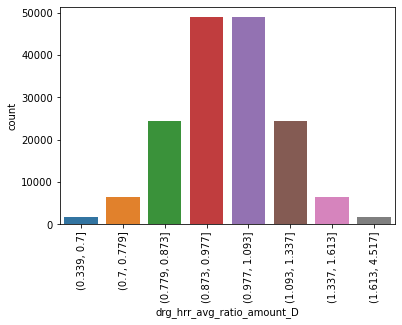

```python
g = sns.countplot(x="drg_hrr_avg_ratio_amount_D", data=df9)
g.set_xticklabels(g.get_xticklabels(), rotation=90)
```

```python
df9[df9['drg_hrr_avg_ratio_amount']>2].head()
```

|  | DRG | Provider_Id | Provider_Name | Provider_StreetAddress | Provider_City | Provider_State | Provider_Zipcode | Hospital_referral_region_desp | Total_Discharges | Average_Total_Payments | Average_Medicare_Payment | HRR | Avg_Payment_ByDRGHrr | drg_hrr_avg_ratio_amount | drg_hrr_avg_ratio_amount_D |
| --- | --- | --- | --- | --- | --- | --- | --- | --- | --- | --- | --- | --- | --- | --- | --- |
| 1554 | 057 - DEGENERATIVE NERVOUS SYSTEM DISORDERS W/... | 210009 | JOHNS HOPKINS HOSPITAL, THE | 600 NORTH WOLFE STREET | BALTIMORE | MD | 21287 | MD - Baltimore | 83 | 24865.61 | 22873.49 | MD - Baltimore | 9017.156000 | 2.536663 | (1.613, 4.517] |
| 1566 | 057 - DEGENERATIVE NERVOUS SYSTEM DISORDERS W/... | 210029 | JOHNS HOPKINS BAYVIEW MEDICAL CENTER | 4940 EASTERN AVENUE | BALTIMORE | MD | 21224 | MD - Baltimore | 103 | 19700.60 | 18407.07 | MD - Baltimore | 9017.156000 | 2.041339 | (1.613, 4.517] |
| 1886 | 057 - DEGENERATIVE NERVOUS SYSTEM DISORDERS W/... | 330234 | WESTCHESTER MEDICAL CENTER | 100 WOODS RD | VALHALLA | NY | 10595 | NY - White Plains | 24 | 17129.08 | 16369.29 | NY - White Plains | 7279.557273 | 2.248666 | (1.613, 4.517] |
| 2138 | 057 - DEGENERATIVE NERVOUS SYSTEM DISORDERS W/... | 450018 | UNIVERSITY OF TEXAS MEDICAL BRANCH GAL | 301 UNIVERSITY BOULEVARD | GALVESTON | TX | 77555 | TX - Houston | 16 | 14123.06 | 13205.31 | TX - Houston | 6001.717143 | 2.200255 | (1.613, 4.517] |
| 2461 | 064 - INTRACRANIAL HEMORRHAGE OR CEREBRAL INFA... | 50348 | UNIVERSITY OF CALIFORNIA IRVINE MED CENTER | 101 CITY DRIVE SOUTH | ORANGE | CA | 92868 | CA - Orange County | 26 | 33918.23 | 33054.88 | CA - Orange County | 15352.735714 | 2.153029 | (1.613, 4.517] |

```python
df['drg_hrr_avg_ratio_amount'] = df9['drg_hrr_avg_ratio_amount']
```

Conclusion: The feature can detect hospital receive more payment (abuse resources) than the average treatment payment among peers in the same hospital referral region and for the same treatment. The higher the ratio, the higher the likelihood.

#### Section 3.2.10: The ratio to median average medicare payment by RDG and HRR

- Notice the only difference to the above code is "median".

```python
# create median average medicare payment group by DRG and HRR
benchmark = data.groupby(['DRG','HRR'])['Average_Medicare_Payment'].median().reset_index()
benchmark.columns = ['DRG','HRR','Median_Payment_ByDRGHrr']
benchmark.head()
```

|  | DRG | HRR | Median_Payment_ByDRGHrr |
| --- | --- | --- | --- |
| 0 | 039 - EXTRACRANIAL PROCEDURES W/O CC/MCC | AK - Anchorage | 6413.780 |
| 1 | 039 - EXTRACRANIAL PROCEDURES W/O CC/MCC | AL - Birmingham | 4471.680 |
| 2 | 039 - EXTRACRANIAL PROCEDURES W/O CC/MCC | AL - Dothan | 4585.965 |
| 3 | 039 - EXTRACRANIAL PROCEDURES W/O CC/MCC | AL - Huntsville | 4868.755 |
| 4 | 039 - EXTRACRANIAL PROCEDURES W/O CC/MCC | AL - Mobile | 4219.900 |

```python
# add the benchmark to the dataset
df10 = pd.merge(data, benchmark, how='left', on=['DRG','HRR'])
# Feature 10: ratio of average medicare payment and median average medicare payment by DRG and HRR
df10['drg_hrr_median_ratio_amount'] = np.where(df10['Median_Payment_ByDRGHrr']==0,0, df10['Average_Medicare_Payment'] / df10['Median_Payment_ByDRGHrr'])
df10['drg_hrr_median_ratio_amount'].describe()
```

```
count    163065.000000
mean          1.038494
std           0.196388
min           0.331728
25%           0.935187
50%           1.000000
75%           1.082952
max           5.733904
Name: drg_hrr_median_ratio_amount, dtype: float64
```

```python
# cut by percentile for plotting
var = 'drg_hrr_median_ratio_amount'
binned_var = var + '_D'
percentile = [0,0.01,0.05,0.2,0.5,0.8,0.95,0.99,1]
df10[binned_var] = pd.qcut(df10[var],percentile)
```

[output not shown]

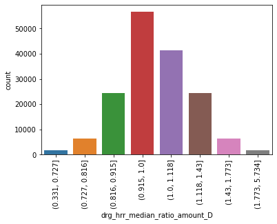

```python
g = sns.countplot(x="drg_hrr_median_ratio_amount_D", data=df10)
g.set_xticklabels(g.get_xticklabels(), rotation=90)
```

```python
df10[df10['drg_hrr_median_ratio_amount']>2].head()
```

|  | DRG | Provider_Id | Provider_Name | Provider_StreetAddress | Provider_City | Provider_State | Provider_Zipcode | Hospital_referral_region_desp | Total_Discharges | Average_Total_Payments | Average_Medicare_Payment | HRR | Median_Payment_ByDRGHrr | drg_hrr_median_ratio_amount | drg_hrr_median_ratio_amount_D |
| --- | --- | --- | --- | --- | --- | --- | --- | --- | --- | --- | --- | --- | --- | --- | --- |
| 456 | 039 - EXTRACRANIAL PROCEDURES W/O CC/MCC | 210029 | JOHNS HOPKINS BAYVIEW MEDICAL CENTER | 4940 EASTERN AVENUE | BALTIMORE | MD | 21224 | MD - Baltimore | 11 | 16878.45 | 15855.18 | MD - Baltimore | 7541.520 | 2.102385 | (1.773, 5.734] |
| 690 | 039 - EXTRACRANIAL PROCEDURES W/O CC/MCC | 330195 | LONG ISLAND JEWISH MEDICAL CENTER | 270 - 05 76TH AVENUE | NEW HYDE PARK | NY | 11040 | NY - East Long Island | 11 | 13895.09 | 13280.54 | NY - East Long Island | 5902.065 | 2.250151 | (1.773, 5.734] |
| 1172 | 057 - DEGENERATIVE NERVOUS SYSTEM DISORDERS W/... | 50276 | CONTRA COSTA REGIONAL MEDICAL CENTER | 2500 ALHAMBRA AVE | MARTINEZ | CA | 94553 | CA - Contra Costa County | 23 | 19239.30 | 18363.08 | CA - Contra Costa County | 7382.920 | 2.487238 | (1.773, 5.734] |
| 1186 | 057 - DEGENERATIVE NERVOUS SYSTEM DISORDERS W/... | 50376 | LAC/HARBOR-UCLA MED CENTER | 1000 W CARSON ST | TORRANCE | CA | 90509 | CA - Los Angeles | 13 | 15070.23 | 14381.00 | CA - Los Angeles | 6956.130 | 2.067385 | (1.773, 5.734] |
| 1547 | 057 - DEGENERATIVE NERVOUS SYSTEM DISORDERS W/... | 210002 | UNIVERSITY OF MARYLAND MEDICAL CENTER | 22 S GREENE ST | BALTIMORE | MD | 21201 | MD - Baltimore | 55 | 17210.74 | 15860.05 | MD - Baltimore | 7217.850 | 2.197337 | (1.773, 5.734] |

```python
df['drg_hrr_median_ratio_amount'] = df10['drg_hrr_median_ratio_amount']
```

Conclusion: The feature can detect hospital receive more payment (abuse resources) than the average treatment payment among peers in the same hospital referral region and for the same treatment. The higher the ratio, the higher the likelihood.

## Section 4: Modeling

#### Thought process:

```python
# aggregate 14 created features
features = df.iloc[:,12:22]
features.head()
```

|  | drg_avg_ratio_amount | drg_median_ratio_amount | drg_state_avg_ratio_amount | drg_state_median_ratio_amount | drg_state_city_avg_ratio_amount | drg_state_city_median_ratio_amount | hrr_avg_ratio_amount | hrr_median_ratio_amount | drg_hrr_avg_ratio_amount | drg_hrr_median_ratio_amount |
| --- | --- | --- | --- | --- | --- | --- | --- | --- | --- | --- |
| 0 | 0.857428 | 0.904057 | 1.035685 | 1.065311 | 1.038763 | 1.038763 | 0.792259 | 1.054827 | 1.038763 | 1.038763 |
| 1 | 0.895762 | 0.944476 | 1.081989 | 1.112940 | 1.000000 | 1.000000 | 0.756673 | 1.016441 | 1.080948 | 1.112940 |
| 2 | 0.801642 | 0.845237 | 0.968301 | 0.995999 | 1.000000 | 1.000000 | 0.677166 | 0.909640 | 0.967369 | 0.995999 |
| 3 | 0.743211 | 0.783629 | 0.897723 | 0.923402 | 0.899200 | 0.953870 | 0.627809 | 0.843338 | 0.896859 | 0.923402 |
| 4 | 0.873215 | 0.920703 | 1.054754 | 1.084926 | 1.000000 | 1.000000 | 0.737626 | 0.990856 | 1.053739 | 1.084926 |

```python
# split train and test by 80/20
from sklearn.model_selection import train_test_split
X_train, X_test = train_test_split(features, test_size = 0.2, random_state = 0)
```

```python
# Standardize train and test
from pyod.utils.utility import standardizer
X_train_norm, X_test_norm = standardizer(X_train, X_test)
```

### Section 4.1: Histogram-based Outlier Detection (HBOS)

#### What is Histogram-based Outlier Detection?

- Histogram-based Outlier Detection is an unsupervised machine learning technique used to detect outliers in multivariate data in terms of all variables.
- HBOS constructs histograms for each of the variables (If a feature d is numerical, bin it to get its histogram; if it is categorical, just count the values of each category) and use the the height of the bin where the data point locates in developing the outlier score. Inverse the hieght of a bin to used as the outlier score becuase we would like to see a small outlier score for normal data and a large score for an outlier. The HBOS is a sum of the logarithmic outlier score of all features.
- The larger the outlier score, the more likely the data point is an outlier.
- Once determine a reasonable boundary of outlier score, can group the data into normal and abnormal cluster to find out the anomalies.

#### Modeling Process

- aggreagte 15 hbos models with different number of bins to achieve model stability and reduce overfitting risk

```python
from pyod.models.hbos import HBOS
from pyod.models.combination import aom, moa, average, maximization

# Test a range of bins
n_clf = 15
k_list = [10,20,30,40,50,60,70,80,90,100,120,150,170,200,300]
# Just prepare data frames so we can store the model results
train_scores = np.zeros([X_train.shape[0], n_clf])
test_scores = np.zeros([X_test.shape[0], n_clf])
train_scores.shape
# Modeling
for i in range(n_clf):
    k = k_list[i]
    hbos = HBOS(n_bins=k)
    hbos.fit(X_train_norm)

    # Store the results in each column:
    train_scores[:, i] = hbos.decision_scores_
    test_scores[:, i] = hbos.decision_function(X_test_norm)
# Decision scores have to be normalized before combination
train_scores_norm, test_scores_norm = standardizer(train_scores,test_scores)
```

- Combination by average

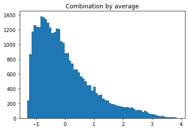

```python
# Combination by average
y_by_average = average(test_scores_norm)
import matplotlib.pyplot as plt
plt.hist(y_by_average, bins='auto') # arguments are passed to np.histogram
plt.title("Combination by average")
plt.show()
```

cluster groups (normal vs abnormal) by the boundary of outlier score of 3.

```python
df_test_avg = X_test.copy()
df_test_avg['y_by_average_score'] = y_by_average
df_test_avg['y_by_average_cluster'] = np.where(df_test_avg['y_by_average_score']<3, 0, 1)
df_test_avg['y_by_average_cluster'].value_counts()
```

```
0    32335
1      278
Name: y_by_average_cluster, dtype: int64
```

The combination by average model identifies 278 data points that have the outlier scores higher than 3

Below is the summary statistics of the two clusters with each feature score

```python
df_test_avg.groupby("y_by_average_cluster").mean()
```

| y_by_average_cluster | drg_avg_ratio_amount | drg_median_ratio_amount | drg_state_avg_ratio_amount | drg_state_median_ratio_amount | drg_state_city_avg_ratio_amount | drg_state_city_median_ratio_amount | hrr_avg_ratio_amount | hrr_median_ratio_amount | drg_hrr_avg_ratio_amount | drg_hrr_median_ratio_amount | y_by_average_score |
| --- | --- | --- | --- | --- | --- | --- | --- | --- | --- | --- | --- |
| 0 | 0.991826 | 1.082484 | 0.992518 | 1.047500 | 0.996135 | 1.004375 | 0.986611 | 1.340598 | 0.993871 | 1.031285 | -0.027885 |
| 1 | 1.807651 | 1.967730 | 1.739085 | 1.851973 | 1.402395 | 1.505788 | 2.810031 | 3.860435 | 1.595929 | 1.736060 | 3.288795 |

The average statistics of the abnormal cluster are much higher than the normal cluster, so those providers in the cluster deserve careful inspection.

- Combination by the maximum of maximum

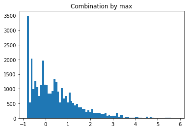

```python
# Combination by mom
y_by_maximization = maximization(test_scores_norm)
import matplotlib.pyplot as plt
plt.hist(y_by_maximization, bins='auto')  # arguments are passed to np.histogram
plt.title("Combination by max")
plt.show()
```

cluster groups (normal vs abnormal) by the boundary of outlier score of 3.

```python
df_test_mom = X_test.copy()
df_test_mom['y_by_maximization_score'] = y_by_maximization
df_test_mom['y_by_maximization_cluster'] = np.where(df_test_mom['y_by_maximization_score']<3, 0, 1)
df_test_mom['y_by_maximization_cluster'].value_counts()
```

```
0    31730
1      883
Name: y_by_maximization_cluster, dtype: int64
```

The combination by maximum of maximum model identifies 883 data points that have the outlier scores higher than 3

Below is the summary statistics of the two clusters with each feature score

```python
df_test_mom.groupby("y_by_maximization_cluster").mean()
```

| y_by_maximization_cluster | drg_avg_ratio_amount | drg_median_ratio_amount | drg_state_avg_ratio_amount | drg_state_median_ratio_amount | drg_state_city_avg_ratio_amount | drg_state_city_median_ratio_amount | hrr_avg_ratio_amount | hrr_median_ratio_amount | drg_hrr_avg_ratio_amount | drg_hrr_median_ratio_amount | y_by_maximization_score |
| --- | --- | --- | --- | --- | --- | --- | --- | --- | --- | --- | --- |
| 0 | 0.979879 | 1.069418 | 0.981127 | 1.035180 | 0.990912 | 0.997992 | 0.971949 | 1.320220 | 0.984211 | 1.020075 | 0.313070 |
| 1 | 1.677957 | 1.830706 | 1.636875 | 1.743506 | 1.311724 | 1.391612 | 2.087564 | 2.866211 | 1.530534 | 1.655998 | 3.638895 |

The average statistics of the abnormal cluster are much higher than the normal cluster, so those providers in the cluster deserve careful inspection.

- combination by average of maximum

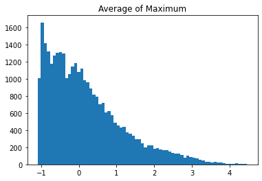

```python
# Combination by aom
y_by_aom = aom(test_scores_norm, n_buckets=5, random_state = 0)
import matplotlib.pyplot as plt
plt.hist(y_by_aom, bins='auto')  # arguments are passed to np.histogram
plt.title("Average of Maximum")
plt.show()
```

cluster groups (normal vs abnormal) by the boundary of outlier score of 3.

```python
df_test_aom = X_test.copy()
df_test_aom['y_by_aom_score'] = y_by_aom
df_test_aom['y_by_aom_cluster'] = np.where(df_test_aom['y_by_aom_score']<3, 0, 1)
df_test_aom['y_by_aom_cluster'].value_counts()
```

```
0    32127
1      486
Name: y_by_aom_cluster, dtype: int64
```

Below is the summary statistics of the two clusters with each feature score

```python
df_test_aom.groupby("y_by_aom_cluster").mean()
```

| y_by_aom_cluster | drg_avg_ratio_amount | drg_median_ratio_amount | drg_state_avg_ratio_amount | drg_state_median_ratio_amount | drg_state_city_avg_ratio_amount | drg_state_city_median_ratio_amount | hrr_avg_ratio_amount | hrr_median_ratio_amount | drg_hrr_avg_ratio_amount | drg_hrr_median_ratio_amount | y_by_aom_score |
| --- | --- | --- | --- | --- | --- | --- | --- | --- | --- | --- | --- |
| 0 | 0.987056 | 1.077274 | 0.988076 | 1.042677 | 0.994184 | 1.002006 | 0.979929 | 1.331310 | 0.990153 | 1.026958 | 0.141346 |
| 1 | 1.773819 | 1.933272 | 1.713208 | 1.826502 | 1.357473 | 1.447772 | 2.471352 | 3.395978 | 1.584026 | 1.720412 | 3.418490 |

The average statistics of the abnormal cluster are much higher than the normal cluster, so those providers in the cluster deserve careful inspection.

- combination by maximum of average

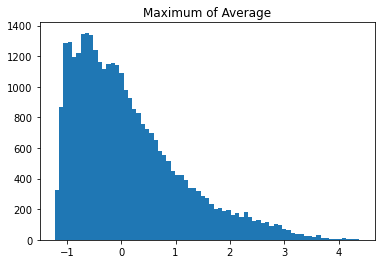

```python
# Combination by moa
y_by_moa = moa(test_scores_norm, n_buckets=5, random_state = 0)
import matplotlib.pyplot as plt
plt.hist(y_by_moa, bins='auto')  # arguments are passed to np.histogram
plt.title("Maximum of Average")
plt.show()
```

cluster groups (normal vs abnormal) by the boundary of outlier score of 3.

```python
df_test_moa = X_test.copy()
df_test_moa['y_by_moa_score'] = y_by_moa
df_test_moa['y_by_moa_cluster'] = np.where(df_test_moa['y_by_moa_score']<3, 0, 1)
df_test_moa['y_by_moa_cluster'].value_counts()
```

```
0    32222
1      391
Name: y_by_moa_cluster, dtype: int64
```

Below is the summary statistics of the two clusters with each feature score

```python
df_test_moa.groupby("y_by_moa_cluster").mean()
```

| y_by_moa_cluster | drg_avg_ratio_amount | drg_median_ratio_amount | drg_state_avg_ratio_amount | drg_state_median_ratio_amount | drg_state_city_avg_ratio_amount | drg_state_city_median_ratio_amount | hrr_avg_ratio_amount | hrr_median_ratio_amount | drg_hrr_avg_ratio_amount | drg_hrr_median_ratio_amount | y_by_moa_score |
| --- | --- | --- | --- | --- | --- | --- | --- | --- | --- | --- | --- |
| 0 | 0.989150 | 1.079558 | 0.989964 | 1.044718 | 0.995036 | 1.003071 | 0.982834 | 1.335366 | 0.991774 | 1.028878 | 0.091739 |
| 1 | 1.792406 | 1.953046 | 1.733787 | 1.848746 | 1.375564 | 1.468339 | 2.594334 | 3.563404 | 1.594701 | 1.730743 | 3.408663 |

The average statistics of the abnormal cluster are much higher than the normal cluster, so those providers in the cluster deserve careful inspection.

```python
# create a new dataframe for abnromal data cluster for further exploration
outliers = df_test_avg[df_test_avg['y_by_average_cluster'] == 1]
outl_df = pd.merge(data, outliers, left_index = True, right_index = True)
outl_df.head()
```

|  | DRG | Provider_Id | Provider_Name | Provider_StreetAddress | Provider_City | Provider_State | Provider_Zipcode | Hospital_referral_region_desp | Total_Discharges | Average_Total_Payments | ... | drg_state_avg_ratio_amount | drg_state_median_ratio_amount | drg_state_city_avg_ratio_amount | drg_state_city_median_ratio_amount | hrr_avg_ratio_amount | hrr_median_ratio_amount | drg_hrr_avg_ratio_amount | drg_hrr_median_ratio_amount | y_by_average_score | y_by_average_cluster |
| --- | --- | --- | --- | --- | --- | --- | --- | --- | --- | --- | --- | --- | --- | --- | --- | --- | --- | --- | --- | --- | --- |
| 2362 | 064 - INTRACRANIAL HEMORRHAGE OR CEREBRAL INFA... | 40118 | NEA BAPTIST MEMORIAL HOSPITAL | 3024 STADIUM BOULEVARD | JONESBORO | AR | 72401 | AR - Jonesboro | 12 | 17535.25 | ... | 1.680076 | 1.761553 | 1.260888 | 1.260888 | 2.417227 | 3.266142 | 1.445534 | 1.705951 | 3.120021 | 1 |
| 2480 | 064 - INTRACRANIAL HEMORRHAGE OR CEREBRAL INFA... | 50454 | UCSF MEDICAL CENTER | 505 PARNASSUS AVE, BOX 0296 | SAN FRANCISCO | CA | 94143 | CA - San Francisco | 53 | 30412.15 | ... | 1.833694 | 1.984117 | 1.220723 | 1.337956 | 2.005571 | 2.730976 | 1.315682 | 1.398493 | 3.267283 | 1 |
| 2589 | 064 - INTRACRANIAL HEMORRHAGE OR CEREBRAL INFA... | 100022 | JACKSON MEMORIAL HOSPITAL | 1611 NW 12TH AVE | MIAMI | FL | 33136 | FL - Miami | 55 | 26157.76 | ... | 2.367860 | 2.582626 | 1.619834 | 1.806227 | 2.572330 | 3.541316 | 1.788899 | 1.817781 | 3.707241 | 1 |
| 2839 | 064 - INTRACRANIAL HEMORRHAGE OR CEREBRAL INFA... | 140281 | NORTHWESTERN MEMORIAL HOSPITAL | 251 E HURON ST | CHICAGO | IL | 60611 | IL - Chicago | 56 | 23337.17 | ... | 1.900899 | 2.049927 | 1.410987 | 1.436893 | 2.087809 | 2.845390 | 1.410987 | 1.436893 | 3.443399 | 1 |
| 2860 | 064 - INTRACRANIAL HEMORRHAGE OR CEREBRAL INFA... | 150024 | WILLIAM N WISHARD MEMORIAL HOSPITAL | 1001 W 10TH ST | INDIANAPOLIS | IN | 46202 | IN - Indianapolis | 25 | 18639.52 | ... | 1.738236 | 1.798411 | 1.425355 | 1.571500 | 2.355752 | 3.188626 | 1.645191 | 1.757922 | 3.351110 | 1 |

5 rows × 24 columns

### Section 4.2: Principal Component Analysis (PCA)

#### What is Principal Component Analysis?

- Principal Component Analysis is a dimension reduction technique to reduce the dimensionality of a dataset consisting of a large number of related variables while retaining as much variance in the data as possible. PCA finds a set of new variables that the original variables are just their linear combinations. The new variables are called Principal Components (PCs).
- D.M.Hawkins said: "An outlier is an observation which deviates so much from the other observations as to arouse suspicions that it was generated by a different mechanism." So once the dimensions are reduced to fewer prinicpal dimension, patterns can be identified and can find outliers.
- Anomaly detection is a by-product of dimension reduction.

```python
from pyod.models.pca import PCA

# Just prepare data frames so we can store the model results
train_scores = np.zeros([X_train.shape[0], 1])
test_scores = np.zeros([X_test.shape[0], 1])
# Modeling
pca = PCA()
pca.fit(X_train_norm)

# Store the results in each column:
train_scores[:,0] = pca.decision_scores_
test_scores[:,0] = pca.decision_function(X_test_norm)
# Decision scores have to be normalized before combination
train_scores_norm, test_scores_norm = standardizer(train_scores,test_scores)
```

```python
pca.explained_variance_ratio_
```

```
array([6.05927516e-01, 1.88871269e-01, 1.20946021e-01, 5.09652083e-02,
       2.29560779e-02, 5.82079864e-03, 3.29571275e-03, 1.05944634e-03,
       8.14344208e-05, 7.65163973e-05])
```

The first principal component accounts for 60.59% variance, the second accounts for 18.88% variance. 91.56% of information is captured by the first, second, and third principal components. 97% of information is captured by the first four principal components.

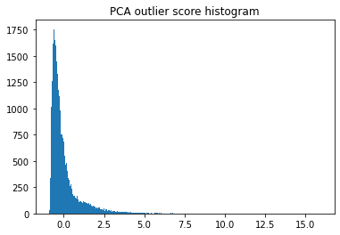

```python
import matplotlib.pyplot as plt
plt.hist(test_scores_norm, bins='auto') # arguments are passed to np.histogram
plt.title('PCA outlier score histogram')
plt.show()
```

cluster groups (normal vs abnormal) by the boundary of outlier score of 3.

```python
df_test_pca = X_test.copy()
df_test_pca['y_score'] = test_scores_norm
df_test_pca['y_cluster'] = np.where(df_test_pca['y_score']<3, 0, 1)
df_test_pca['y_cluster'].value_counts()
```

```
0    31938
1      675
Name: y_cluster, dtype: int64
```

The PCA model identifies 675 data points that have the outlier scores higher than 3

Below is the summary statistics of the two clusters with each feature score

```python
df_test_pca.groupby("y_cluster").mean()
```

| y_cluster | drg_avg_ratio_amount | drg_median_ratio_amount | drg_state_avg_ratio_amount | drg_state_median_ratio_amount | drg_state_city_avg_ratio_amount | drg_state_city_median_ratio_amount | hrr_avg_ratio_amount | hrr_median_ratio_amount | drg_hrr_avg_ratio_amount | drg_hrr_median_ratio_amount | y_score |
| --- | --- | --- | --- | --- | --- | --- | --- | --- | --- | --- | --- |
| 0 | 0.981046 | 1.070612 | 0.983512 | 1.037419 | 0.992488 | 0.999940 | 0.977358 | 1.327725 | 0.986999 | 1.023471 | -0.093520 |
| 1 | 1.837883 | 2.008820 | 1.726111 | 1.855817 | 1.336014 | 1.420693 | 2.175417 | 2.987488 | 1.566951 | 1.691267 | 4.316213 |

The average statistics of the abnormal cluster are much higher than the normal cluster, so those providers in the cluster deserve careful inspection.

```python
# create a new dataframe for abnromal data cluster for further exploration
outliers = df_test_pca[df_test_pca['y_cluster'] == 1]
outl_df = pd.merge(data, outliers, left_index = True, right_index = True)
outl_df.head()
```

|  | DRG | Provider_Id | Provider_Name | Provider_StreetAddress | Provider_City | Provider_State | Provider_Zipcode | Hospital_referral_region_desp | Total_Discharges | Average_Total_Payments | ... | drg_state_avg_ratio_amount | drg_state_median_ratio_amount | drg_state_city_avg_ratio_amount | drg_state_city_median_ratio_amount | hrr_avg_ratio_amount | hrr_median_ratio_amount | drg_hrr_avg_ratio_amount | drg_hrr_median_ratio_amount | y_score | y_cluster |
| --- | --- | --- | --- | --- | --- | --- | --- | --- | --- | --- | --- | --- | --- | --- | --- | --- | --- | --- | --- | --- | --- |
| 755 | 039 - EXTRACRANIAL PROCEDURES W/O CC/MCC | 360059 | METRO HEALTH MEDICAL CENTER | 2500 METROHEALTH DRIVE | CLEVELAND | OH | 44109 | OH - Cleveland | 12 | 9506.58 | ... | 1.678649 | 1.777887 | 1.365272 | 1.460607 | 1.115885 | 1.536648 | 1.676181 | 1.784044 | 3.412865 | 1 |
| 1207 | 057 - DEGENERATIVE NERVOUS SYSTEM DISORDERS W/... | 50599 | UNIVERSITY OF CALIFORNIA DAVIS MEDICAL CENTER | 2315 STOCKTON BOULEVARD | SACRAMENTO | CA | 95817 | CA - Sacramento | 22 | 12360.90 | ... | 1.530748 | 1.689677 | 1.276121 | 1.276121 | 1.033859 | 1.445429 | 1.613316 | 1.834124 | 3.341118 | 1 |
| 2174 | 057 - DEGENERATIVE NERVOUS SYSTEM DISORDERS W/... | 450289 | HARRIS COUNTY HOSPITAL DISTRICT | 2525 HOLLY HALL | HOUSTON | TX | 77054 | TX - Houston | 16 | 9726.62 | ... | 1.694381 | 1.798626 | 1.502801 | 1.712449 | 1.060458 | 1.471904 | 1.480180 | 1.787112 | 4.166763 | 1 |
| 2480 | 064 - INTRACRANIAL HEMORRHAGE OR CEREBRAL INFA... | 50454 | UCSF MEDICAL CENTER | 505 PARNASSUS AVE, BOX 0296 | SAN FRANCISCO | CA | 94143 | CA - San Francisco | 53 | 30412.15 | ... | 1.833694 | 1.984117 | 1.220723 | 1.337956 | 2.005571 | 2.730976 | 1.315682 | 1.398493 | 3.900571 | 1 |
| 2589 | 064 - INTRACRANIAL HEMORRHAGE OR CEREBRAL INFA... | 100022 | JACKSON MEMORIAL HOSPITAL | 1611 NW 12TH AVE | MIAMI | FL | 33136 | FL - Miami | 55 | 26157.76 | ... | 2.367860 | 2.582626 | 1.619834 | 1.806227 | 2.572330 | 3.541316 | 1.788899 | 1.817781 | 6.755832 | 1 |

5 rows × 24 columns

### Section 4.3: iForest

#### What is Isolated Forest?

- Isolation Forest is an unsupervised machine learning technique for anomaly detection. It is an alternative approach to detect anomolies by explicitly isolating anomalies instead of profiling nromal data points.
- Anomalies are the data points closer to the root of the trees and have short path lenghts on a tree because outliers are easy to be separated and normal data points require more tree branches to reach. The number of depths becomes a good proxy for the anomaly score and the anomaly score is defined as the inverse of the number of depths.
- The larger the outlier score, the more likely the data point is an outlier.
- Once determine a reasonable boundary of outlier score, can group the data into normal and abnormal cluster to find out the anomalies.

#### Modeling Process

- aggreagte 10 iforest models with different max_samples to achieve model stability and reduce overfitting risk

```python
from pyod.models.iforest import IForest
from pyod.models.combination import aom, moa, average, maximization

# Test a range of max_samples
n_clf = 10
sample_list = [50,100,150,200,250,300,350,400,450,500]
# Just prepare data frames so we can store the model results
train_scores = np.zeros([X_train.shape[0], n_clf])
test_scores = np.zeros([X_test.shape[0], n_clf])
# Modeling
for i in range(n_clf):
    k = sample_list[i]
    forest = IForest(behaviour="new", max_samples=k, random_state = 0)
    forest.fit(X_train_norm)

    # Store the results in each column:
    train_scores[:, i] = forest.decision_scores_
    test_scores[:, i] = forest.decision_function(X_test_norm)
# Decision scores have to be normalized before combination
train_scores_norm, test_scores_norm = standardizer(train_scores,test_scores)
```

- Combination by average

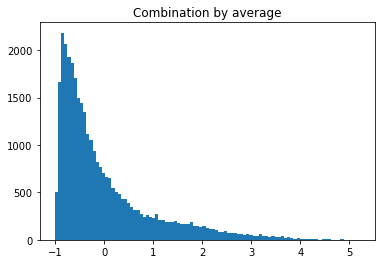

```python
# Combination by average
y_by_average = average(test_scores_norm)
import matplotlib.pyplot as plt
plt.hist(y_by_average, bins='auto') # arguments are passed to np.histogram
plt.title("Combination by average")
plt.show()
```

cluster groups (normal vs abnormal) by the boundary of outlier score of 3.

```python
df_test_avg = X_test.copy()
df_test_avg['y_by_average_score'] = y_by_average
df_test_avg['y_by_average_cluster'] = np.where(df_test_avg['y_by_average_score']<3, 0, 1)
df_test_avg['y_by_average_cluster'].value_counts()
```

```
0    32018
1      595
Name: y_by_average_cluster, dtype: int64
```

The combination by average model identifies 595 data points that have the outlier scores higher than 3

Below is the summary statistics of the two clusters with each feature score

```python
df_test_avg.groupby("y_by_average_cluster").mean()
```

| y_by_average_cluster | drg_avg_ratio_amount | drg_median_ratio_amount | drg_state_avg_ratio_amount | drg_state_median_ratio_amount | drg_state_city_avg_ratio_amount | drg_state_city_median_ratio_amount | hrr_avg_ratio_amount | hrr_median_ratio_amount | drg_hrr_avg_ratio_amount | drg_hrr_median_ratio_amount | y_by_average_score |
| --- | --- | --- | --- | --- | --- | --- | --- | --- | --- | --- | --- |
| 0 | 0.982389 | 1.072114 | 0.985424 | 1.039434 | 0.993802 | 1.001602 | 0.976301 | 1.326354 | 0.988814 | 1.025560 | -0.065428 |
| 1 | 1.880779 | 2.054143 | 1.723068 | 1.857428 | 1.311486 | 1.387856 | 2.393353 | 3.284408 | 1.547295 | 1.668615 | 3.567023 |

The average statistics of the abnormal cluster are much higher than the normal cluster, so those providers in the cluster deserve careful inspection.

- Combination by maximum of maximum

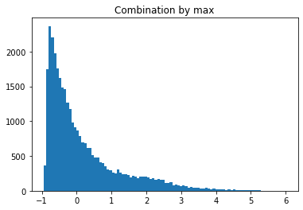

```python
# Combination by max
y_by_mom = maximization(test_scores_norm)
import matplotlib.pyplot as plt
plt.hist(y_by_mom, bins='auto') # arguments are passed to np.histogram
plt.title("Combination by max")
plt.show()
```

cluster groups (normal vs abnormal) by the boundary of outlier score of 3.

```python
df_test_mom = X_test.copy()
df_test_mom['y_by_mom_score'] = y_by_mom
df_test_mom['y_by_mom_cluster'] = np.where(df_test_mom['y_by_mom_score']<3, 0, 1)
df_test_mom['y_by_mom_cluster'].value_counts()
```

```
0    31787
1      826
Name: y_by_mom_cluster, dtype: int64
```

Below is the summary statistics of the two clusters with each feature score

```python
df_test_mom.groupby("y_by_mom_cluster").mean()
```

| y_by_mom_cluster | drg_avg_ratio_amount | drg_median_ratio_amount | drg_state_avg_ratio_amount | drg_state_median_ratio_amount | drg_state_city_avg_ratio_amount | drg_state_city_median_ratio_amount | hrr_avg_ratio_amount | hrr_median_ratio_amount | drg_hrr_avg_ratio_amount | drg_hrr_median_ratio_amount | y_by_mom_score |
| --- | --- | --- | --- | --- | --- | --- | --- | --- | --- | --- | --- |
| 0 | 0.978837 | 1.068239 | 0.982627 | 1.036292 | 0.992961 | 1.000575 | 0.968901 | 1.316144 | 0.986892 | 1.023385 | 0.072005 |
| 1 | 1.766256 | 1.928619 | 1.624408 | 1.749593 | 1.255008 | 1.319356 | 2.281835 | 3.129751 | 1.465065 | 1.572502 | 3.707934 |

The average statistics of the abnormal cluster are much higher than the normal cluster, so those providers in the cluster deserve careful inspection.

- Combination by maximum of average

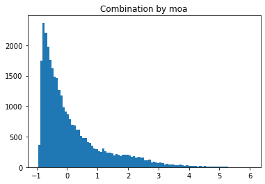

```python
# Combination by moa
y_by_moa = moa(test_scores_norm, n_buckets = 10, random_state = 0)
import matplotlib.pyplot as plt
plt.hist(y_by_moa, bins='auto') # arguments are passed to np.histogram
plt.title("Combination by moa")
plt.show()
```

cluster groups (normal vs abnormal) by the boundary of outlier score of 3.

```python
df_test_moa = X_test.copy()
df_test_moa['y_by_moa_score'] = y_by_moa
df_test_moa['y_by_moa_cluster'] = np.where(df_test_moa['y_by_moa_score']<3, 0, 1)
df_test_moa['y_by_moa_cluster'].value_counts()
```

```
0    31787
1      826
Name: y_by_moa_cluster, dtype: int64
```

Below is the summary statistics of the two clusters with each feature score

```python
df_test_moa.groupby("y_by_moa_cluster").mean()
```

| y_by_moa_cluster | drg_avg_ratio_amount | drg_median_ratio_amount | drg_state_avg_ratio_amount | drg_state_median_ratio_amount | drg_state_city_avg_ratio_amount | drg_state_city_median_ratio_amount | hrr_avg_ratio_amount | hrr_median_ratio_amount | drg_hrr_avg_ratio_amount | drg_hrr_median_ratio_amount | y_by_moa_score |
| --- | --- | --- | --- | --- | --- | --- | --- | --- | --- | --- | --- |
| 0 | 0.978837 | 1.068239 | 0.982627 | 1.036292 | 0.992961 | 1.000575 | 0.968901 | 1.316144 | 0.986892 | 1.023385 | 0.072005 |
| 1 | 1.766256 | 1.928619 | 1.624408 | 1.749593 | 1.255008 | 1.319356 | 2.281835 | 3.129751 | 1.465065 | 1.572502 | 3.707934 |

The average statistics of the abnormal cluster are much higher than the normal cluster, so those providers in the cluster deserve careful inspection.

- Combination by average of maximum

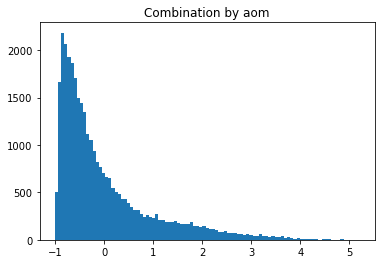

```python
# Combination by aom
y_by_aom = aom(test_scores_norm, n_buckets = 10, random_state = 0)
import matplotlib.pyplot as plt
plt.hist(y_by_aom, bins='auto') # arguments are passed to np.histogram
plt.title("Combination by aom")
plt.show()
```

cluster groups (normal vs abnormal) by the boundary of outlier score of 3.

```python
df_test_aom = X_test.copy()
df_test_aom['y_by_aom_score'] = y_by_aom
df_test_aom['y_by_aom_cluster'] = np.where(df_test_aom['y_by_aom_score']<3, 0, 1)
df_test_aom['y_by_aom_cluster'].value_counts()
```

```
0    32018
1      595
Name: y_by_aom_cluster, dtype: int64
```

Below is the summary statistics of the two clusters with each feature score

```python
df_test_aom.groupby("y_by_aom_cluster").mean()
```

| y_by_aom_cluster | drg_avg_ratio_amount | drg_median_ratio_amount | drg_state_avg_ratio_amount | drg_state_median_ratio_amount | drg_state_city_avg_ratio_amount | drg_state_city_median_ratio_amount | hrr_avg_ratio_amount | hrr_median_ratio_amount | drg_hrr_avg_ratio_amount | drg_hrr_median_ratio_amount | y_by_aom_score |
| --- | --- | --- | --- | --- | --- | --- | --- | --- | --- | --- | --- |
| 0 | 0.982389 | 1.072114 | 0.985424 | 1.039434 | 0.993802 | 1.001602 | 0.976301 | 1.326354 | 0.988814 | 1.025560 | -0.065428 |
| 1 | 1.880779 | 2.054143 | 1.723068 | 1.857428 | 1.311486 | 1.387856 | 2.393353 | 3.284408 | 1.547295 | 1.668615 | 3.567023 |

The average statistics of the abnormal cluster are much higher than the normal cluster, so those providers in the cluster deserve careful inspection.

```python
# create a new dataframe for abnromal data cluster for further exploration
outliers = df_test_avg[df_test_avg['y_by_average_cluster'] == 1]
outl_df = pd.merge(data, outliers, left_index = True, right_index = True)
outl_df.head()
```

|  | DRG | Provider_Id | Provider_Name | Provider_StreetAddress | Provider_City | Provider_State | Provider_Zipcode | Hospital_referral_region_desp | Total_Discharges | Average_Total_Payments | ... | drg_state_avg_ratio_amount | drg_state_median_ratio_amount | drg_state_city_avg_ratio_amount | drg_state_city_median_ratio_amount | hrr_avg_ratio_amount | hrr_median_ratio_amount | drg_hrr_avg_ratio_amount | drg_hrr_median_ratio_amount | y_by_average_score | y_by_average_cluster |
| --- | --- | --- | --- | --- | --- | --- | --- | --- | --- | --- | --- | --- | --- | --- | --- | --- | --- | --- | --- | --- | --- |
| 1183 | 057 - DEGENERATIVE NERVOUS SYSTEM DISORDERS W/... | 50351 | TORRANCE MEMORIAL MEDICAL CENTER | 3330 LOMITA BLVD | TORRANCE | CA | 90509 | CA - Los Angeles | 11 | 7510.36 | ... | 0.567436 | 0.626350 | 0.495962 | 0.597874 | 0.361045 | 0.492621 | 0.587075 | 0.612330 | 3.031496 | 1 |
| 1207 | 057 - DEGENERATIVE NERVOUS SYSTEM DISORDERS W/... | 50599 | UNIVERSITY OF CALIFORNIA DAVIS MEDICAL CENTER | 2315 STOCKTON BOULEVARD | SACRAMENTO | CA | 95817 | CA - Sacramento | 22 | 12360.90 | ... | 1.530748 | 1.689677 | 1.276121 | 1.276121 | 1.033859 | 1.445429 | 1.613316 | 1.834124 | 3.059849 | 1 |
| 2174 | 057 - DEGENERATIVE NERVOUS SYSTEM DISORDERS W/... | 450289 | HARRIS COUNTY HOSPITAL DISTRICT | 2525 HOLLY HALL | HOUSTON | TX | 77054 | TX - Houston | 16 | 9726.62 | ... | 1.694381 | 1.798626 | 1.502801 | 1.712449 | 1.060458 | 1.471904 | 1.480180 | 1.787112 | 3.155090 | 1 |
| 2480 | 064 - INTRACRANIAL HEMORRHAGE OR CEREBRAL INFA... | 50454 | UCSF MEDICAL CENTER | 505 PARNASSUS AVE, BOX 0296 | SAN FRANCISCO | CA | 94143 | CA - San Francisco | 53 | 30412.15 | ... | 1.833694 | 1.984117 | 1.220723 | 1.337956 | 2.005571 | 2.730976 | 1.315682 | 1.398493 | 3.673415 | 1 |
| 2589 | 064 - INTRACRANIAL HEMORRHAGE OR CEREBRAL INFA... | 100022 | JACKSON MEMORIAL HOSPITAL | 1611 NW 12TH AVE | MIAMI | FL | 33136 | FL - Miami | 55 | 26157.76 | ... | 2.367860 | 2.582626 | 1.619834 | 1.806227 | 2.572330 | 3.541316 | 1.788899 | 1.817781 | 4.496100 | 1 |

5 rows × 24 columns